# Regressões

```python
import pandas as pd
import numpy as np
import statsmodels.api as sm
import seaborn as sns
import sklearn as sk
```

```python
sns.set_style('whitegrid')
sns.set_palette('flare_r')
sns.color_palette('flare_r')
```

```python
df_all = pd.read_csv('Dados Tratados/output_geral.csv', sep=';')
```

```python
df_min = pd.read_csv('Dados Tratados/output_owners_min.csv', sep=';')
```

```python
df_max = pd.read_csv('Dados Tratados/output_owners.csv', sep=';')
```

```python
Colunas = ['appid','name','Year','english','platforms_windows','platforms_mac','platforms_linux','genres_Action',
           'genres_Free to Play', 'genres_Strategy','genres_Adventure', 'genres_Indie', 'genres_RPG',
           'genres_Casual','genres_Simulation', 'genres_Racing', 'genres_Violent','genres_Massively Multiplayer',
           'genres_Nudity', 'genres_Sports',       'genres_Early Access', 'genres_Gore', 'genres_Sexual Content',
           'categories_Multi-player', 'categories_Online Multi-Player','categories_Local Multi-Player',
           'categories_Valve Anti-Cheat enabled','categories_Single-player', 'categories_Steam Cloud',
           'categories_Steam Achievements', 'categories_Steam Trading Cards','categories_Captions available',
           'categories_Partial Controller Support','categories_Includes Source SDK','categories_Cross-Platform Multiplayer',
           'categories_Stats','categories_Commentary available', 'categories_Includes level editor',
           'categories_Steam Workshop', 'categories_In-App Purchases','categories_Co-op',
           'categories_Full controller support','categories_Steam Leaderboards', 'categories_SteamVR Collectibles',
           'categories_Online Co-op', 'categories_Shared/Split Screen','categories_Local Co-op', 'categories_MMO',
           'categories_VR Support','categories_Mods', 'categories_Mods (require HL2)',
           'categories_Steam Turn Notifications','achievements','%_ratings','QTD_ratings','owners_mean',
           'average_playtime_>0','price','log_price','log_log_price']
```

```python
Colunas_Tratada = ['Year','english','platforms_windows','platforms_mac','platforms_linux','genres_Action',
           'genres_Free to Play', 'genres_Strategy','genres_Adventure', 'genres_Indie', 'genres_RPG',
           'genres_Casual','genres_Simulation', 'genres_Racing', 'genres_Violent','genres_Massively Multiplayer',
           'genres_Nudity', 'genres_Sports',       'genres_Early Access', 'genres_Gore', 'genres_Sexual Content',
           'categories_Multi-player', 'categories_Online Multi-Player','categories_Local Multi-Player',
           'categories_Valve Anti-Cheat enabled','categories_Single-player', 'categories_Steam Cloud',
           'categories_Steam Achievements', 'categories_Steam Trading Cards','categories_Captions available',
           'categories_Partial Controller Support','categories_Includes Source SDK','categories_Cross-Platform Multiplayer',
           'categories_Stats','categories_Commentary available', 'categories_Includes level editor',
           'categories_Steam Workshop', 'categories_In-App Purchases','categories_Co-op',
           'categories_Full controller support','categories_Steam Leaderboards', 'categories_SteamVR Collectibles',
           'categories_Online Co-op', 'categories_Shared/Split Screen','categories_Local Co-op', 'categories_MMO',
           'categories_VR Support','categories_Mods', 'categories_Mods (require HL2)',
           'categories_Steam Turn Notifications','achievements','%_ratings','QTD_ratings','owners_mean',
           'average_playtime_>0']
```

```python
df_all.head()
```

|  | Unnamed: 0 | appid | name | Year | english | platforms_windows | platforms_mac | platforms_linux | genres_Action | genres_Free to Play | ... | categories_Mods (require HL2) | categories_Steam Turn Notifications | achievements | %_ratings | QTD_ratings | owners_mean | average_playtime_>0 | price | log_price | log_log_price |
| --- | --- | --- | --- | --- | --- | --- | --- | --- | --- | --- | --- | --- | --- | --- | --- | --- | --- | --- | --- | --- | --- |
| 0 | 0 | 10 | Counter-Strike | 2000 | 1 | 1 | 1 | 1 | 1 | 0 | ... | 0 | 0 | 0 | 0.973888 | 127873 | 15000000.0 | 1 | 7.19 | 2.102914 | 1.132342 |
| 1 | 1 | 20 | Team Fortress Classic | 1999 | 1 | 1 | 1 | 1 | 1 | 0 | ... | 0 | 0 | 0 | 0.839787 | 3951 | 7500000.0 | 1 | 3.99 | 1.607436 | 0.958367 |
| 2 | 2 | 30 | Day of Defeat | 2003 | 1 | 1 | 1 | 1 | 1 | 0 | ... | 0 | 0 | 0 | 0.895648 | 3814 | 7500000.0 | 1 | 3.99 | 1.607436 | 0.958367 |
| 3 | 3 | 40 | Deathmatch Classic | 2001 | 1 | 1 | 1 | 1 | 1 | 0 | ... | 0 | 0 | 0 | 0.826623 | 1540 | 7500000.0 | 1 | 3.99 | 1.607436 | 0.958367 |
| 4 | 4 | 50 | Half-Life: Opposing Force | 1999 | 1 | 1 | 1 | 1 | 1 | 0 | ... | 0 | 0 | 0 | 0.947996 | 5538 | 7500000.0 | 1 | 3.99 | 1.607436 | 0.958367 |

5 rows × 61 columns

```python
df_min.head()
```

|  | Unnamed: 0 | appid | name | Year | english | platforms_windows | platforms_mac | platforms_linux | genres_Action | genres_Free to Play | ... | categories_Mods (require HL2) | categories_Steam Turn Notifications | achievements | %_ratings | QTD_ratings | owners_mean | average_playtime_>0 | price | log_price | log_log_price |
| --- | --- | --- | --- | --- | --- | --- | --- | --- | --- | --- | --- | --- | --- | --- | --- | --- | --- | --- | --- | --- | --- |
| 0 | 122 | 4100 | Poker Superstars II | 2006 | 1 | 1 | 0 | 0 | 0 | 0 | ... | 0 | 0 | 0 | 0.444444 | 9 | 10000.0 | 0 | 5.99 | 1.944481 | 1.079932 |
| 1 | 124 | 4290 | RACE: Caterham Expansion | 2007 | 1 | 1 | 0 | 0 | 0 | 0 | ... | 0 | 0 | 0 | 0.666667 | 6 | 10000.0 | 0 | 3.99 | 1.607436 | 0.958367 |
| 2 | 145 | 4900 | Zen of Sudoku | 2006 | 1 | 1 | 0 | 0 | 0 | 0 | ... | 0 | 0 | 0 | 0.877698 | 139 | 10000.0 | 0 | 0.00 | 0.000000 | 0.000000 |
| 3 | 188 | 7340 | Azada | 2010 | 1 | 1 | 0 | 0 | 0 | 0 | ... | 0 | 0 | 0 | 0.666667 | 12 | 10000.0 | 0 | 6.99 | 2.078191 | 1.124342 |
| 4 | 248 | 9960 | Haunted House™ | 2010 | 1 | 1 | 0 | 0 | 0 | 0 | ... | 0 | 0 | 0 | 0.409091 | 22 | 10000.0 | 0 | 4.79 | 1.756132 | 1.013828 |

5 rows × 61 columns

```python
df_max.head()
```

|  | Unnamed: 0 | appid | name | Year | english | platforms_windows | platforms_mac | platforms_linux | genres_Action | genres_Free to Play | ... | categories_Mods (require HL2) | categories_Steam Turn Notifications | achievements | %_ratings | QTD_ratings | owners_mean | average_playtime_>0 | price | log_price | log_log_price |
| --- | --- | --- | --- | --- | --- | --- | --- | --- | --- | --- | --- | --- | --- | --- | --- | --- | --- | --- | --- | --- | --- |
| 0 | 0 | 10 | Counter-Strike | 2000 | 1 | 1 | 1 | 1 | 1 | 0 | ... | 0 | 0 | 0 | 0.973888 | 127873 | 15000000.0 | 1 | 7.19 | 2.102914 | 1.132342 |
| 1 | 1 | 20 | Team Fortress Classic | 1999 | 1 | 1 | 1 | 1 | 1 | 0 | ... | 0 | 0 | 0 | 0.839787 | 3951 | 7500000.0 | 1 | 3.99 | 1.607436 | 0.958367 |
| 2 | 2 | 30 | Day of Defeat | 2003 | 1 | 1 | 1 | 1 | 1 | 0 | ... | 0 | 0 | 0 | 0.895648 | 3814 | 7500000.0 | 1 | 3.99 | 1.607436 | 0.958367 |
| 3 | 3 | 40 | Deathmatch Classic | 2001 | 1 | 1 | 1 | 1 | 1 | 0 | ... | 0 | 0 | 0 | 0.826623 | 1540 | 7500000.0 | 1 | 3.99 | 1.607436 | 0.958367 |
| 4 | 4 | 50 | Half-Life: Opposing Force | 1999 | 1 | 1 | 1 | 1 | 1 | 0 | ... | 0 | 0 | 0 | 0.947996 | 5538 | 7500000.0 | 1 | 3.99 | 1.607436 | 0.958367 |

5 rows × 61 columns

```python
df_all.describe()
```

|  | Unnamed: 0 | appid | Year | english | platforms_windows | platforms_mac | platforms_linux | genres_Action | genres_Free to Play | genres_Strategy | ... | categories_Mods (require HL2) | categories_Steam Turn Notifications | achievements | %_ratings | QTD_ratings | owners_mean | average_playtime_>0 | price | log_price | log_log_price |
| --- | --- | --- | --- | --- | --- | --- | --- | --- | --- | --- | --- | --- | --- | --- | --- | --- | --- | --- | --- | --- | --- |
| count | 26846.000000 | 2.684600e+04 | 26846.000000 | 26846.000000 | 26846.000000 | 26846.000000 | 26846.000000 | 26846.000000 | 26846.000000 | 26846.000000 | ... | 26846.000000 | 26846.000000 | 26846.000000 | 26846.000000 | 2.684600e+04 | 2.684600e+04 | 26846.000000 | 26846.000000 | 26846.000000 | 26846.000000 |
| mean | 13537.970834 | 5.961759e+05 | 2016.496908 | 0.981040 | 0.999814 | 0.299113 | 0.194256 | 0.443306 | 0.063175 | 0.195374 | ... | 0.000037 | 0.002347 | 45.613536 | 0.714424 | 1.217097e+03 | 1.344908e+05 | 0.228600 | 5.999415 | 1.585724 | 0.882937 |
| std | 7817.936144 | 2.510454e+05 | 2.161338 | 0.136386 | 0.013646 | 0.457878 | 0.395634 | 0.496785 | 0.243282 | 0.396495 | ... | 0.006103 | 0.048387 | 354.148334 | 0.233717 | 2.252065e+04 | 1.332872e+06 | 0.419939 | 7.244335 | 0.864164 | 0.387937 |
| min | 0.000000 | 1.000000e+01 | 1997.000000 | 0.000000 | 0.000000 | 0.000000 | 0.000000 | 0.000000 | 0.000000 | 0.000000 | ... | 0.000000 | 0.000000 | 0.000000 | 0.000000 | 1.000000e+00 | 1.000000e+04 | 0.000000 | 0.000000 | 0.000000 | 0.000000 |
| 25% | 6764.250000 | 4.011325e+05 | 2016.000000 | 1.000000 | 1.000000 | 0.000000 | 0.000000 | 0.000000 | 0.000000 | 0.000000 | ... | 0.000000 | 0.000000 | 0.000000 | 0.583333 | 1.000000e+01 | 1.000000e+04 | 0.000000 | 1.690000 | 0.989541 | 0.687904 |
| 50% | 13543.500000 | 5.992850e+05 | 2017.000000 | 1.000000 | 1.000000 | 0.000000 | 0.000000 | 0.000000 | 0.000000 | 0.000000 | ... | 0.000000 | 0.000000 | 7.000000 | 0.760435 | 3.600000e+01 | 1.000000e+04 | 0.000000 | 3.990000 | 1.607436 | 0.958367 |
| 75% | 20310.750000 | 7.989175e+05 | 2018.000000 | 1.000000 | 1.000000 | 1.000000 | 0.000000 | 1.000000 | 0.000000 | 0.000000 | ... | 0.000000 | 0.000000 | 23.000000 | 0.893838 | 1.770000e+02 | 3.500000e+04 | 0.000000 | 7.190000 | 2.102914 | 1.132342 |
| max | 27074.000000 | 1.069460e+06 | 2019.000000 | 1.000000 | 1.000000 | 1.000000 | 1.000000 | 1.000000 | 1.000000 | 1.000000 | ... | 1.000000 | 1.000000 | 9821.000000 | 1.000000 | 3.046717e+06 | 1.500000e+08 | 1.000000 | 421.990000 | 6.047349 | 1.952651 |

8 rows × 60 columns

```python
df_min.describe()
```

|  | Unnamed: 0 | appid | Year | english | platforms_windows | platforms_mac | platforms_linux | genres_Action | genres_Free to Play | genres_Strategy | ... | categories_Mods (require HL2) | categories_Steam Turn Notifications | achievements | %_ratings | QTD_ratings | owners_mean | average_playtime_>0 | price | log_price | log_log_price |
| --- | --- | --- | --- | --- | --- | --- | --- | --- | --- | --- | --- | --- | --- | --- | --- | --- | --- | --- | --- | --- | --- |
| count | 18433.000000 | 1.843300e+04 | 18433.000000 | 18433.000000 | 18433.000000 | 18433.000000 | 18433.000000 | 18433.000000 | 18433.000000 | 18433.000000 | ... | 18433.0 | 18433.000000 | 18433.000000 | 18433.000000 | 18433.000000 | 18433.0 | 18433.000000 | 18433.000000 | 18433.000000 | 18433.000000 |
| mean | 16271.622525 | 6.847525e+05 | 2017.195682 | 0.976781 | 0.999783 | 0.259372 | 0.161395 | 0.435740 | 0.027776 | 0.182065 | ... | 0.0 | 0.002062 | 46.889546 | 0.707029 | 40.729290 | 10000.0 | 0.041827 | 5.501475 | 1.570516 | 0.890951 |
| std | 6881.558945 | 2.120956e+05 | 1.388686 | 0.150603 | 0.014730 | 0.438302 | 0.367905 | 0.495867 | 0.164336 | 0.385908 | ... | 0.0 | 0.045358 | 381.471008 | 0.255186 | 71.600204 | 0.0 | 0.200199 | 6.760558 | 0.778563 | 0.342277 |
| min | 122.000000 | 4.100000e+03 | 2006.000000 | 0.000000 | 0.000000 | 0.000000 | 0.000000 | 0.000000 | 0.000000 | 0.000000 | ... | 0.0 | 0.000000 | 0.000000 | 0.000000 | 1.000000 | 10000.0 | 0.000000 | 0.000000 | 0.000000 | 0.000000 |
| 25% | 10879.000000 | 5.254500e+05 | 2017.000000 | 1.000000 | 1.000000 | 0.000000 | 0.000000 | 0.000000 | 0.000000 | 0.000000 | ... | 0.0 | 0.000000 | 0.000000 | 0.557692 | 6.000000 | 10000.0 | 0.000000 | 1.690000 | 0.989541 | 0.687904 |
| 50% | 16973.000000 | 7.035100e+05 | 2017.000000 | 1.000000 | 1.000000 | 0.000000 | 0.000000 | 0.000000 | 0.000000 | 0.000000 | ... | 0.0 | 0.000000 | 5.000000 | 0.750000 | 17.000000 | 10000.0 | 0.000000 | 3.990000 | 1.607436 | 0.958367 |
| 75% | 22122.000000 | 8.544500e+05 | 2018.000000 | 1.000000 | 1.000000 | 1.000000 | 0.000000 | 1.000000 | 0.000000 | 0.000000 | ... | 0.0 | 0.000000 | 20.000000 | 0.910256 | 42.000000 | 10000.0 | 0.000000 | 7.190000 | 2.102914 | 1.132342 |
| max | 27074.000000 | 1.069460e+06 | 2019.000000 | 1.000000 | 1.000000 | 1.000000 | 1.000000 | 1.000000 | 1.000000 | 1.000000 | ... | 0.0 | 1.000000 | 5394.000000 | 1.000000 | 1880.000000 | 10000.0 | 1.000000 | 421.990000 | 6.047349 | 1.952651 |

8 rows × 60 columns

```python
df_max.describe()
```

|  | Unnamed: 0 | appid | Year | english | platforms_windows | platforms_mac | platforms_linux | genres_Action | genres_Free to Play | genres_Strategy | ... | categories_Mods (require HL2) | categories_Steam Turn Notifications | achievements | %_ratings | QTD_ratings | owners_mean | average_playtime_>0 | price | log_price | log_log_price |
| --- | --- | --- | --- | --- | --- | --- | --- | --- | --- | --- | --- | --- | --- | --- | --- | --- | --- | --- | --- | --- | --- |
| count | 8413.000000 | 8.413000e+03 | 8413.000000 | 8413.000000 | 8413.000000 | 8413.000000 | 8413.000000 | 8413.000000 | 8413.000000 | 8413.000000 | ... | 8413.000000 | 8413.000000 | 8413.000000 | 8413.000000 | 8.413000e+03 | 8.413000e+03 | 8413.000000 | 8413.000000 | 8413.000000 | 8413.000000 |
| mean | 7548.501961 | 4.021034e+05 | 2014.965886 | 0.990372 | 0.999881 | 0.386188 | 0.266255 | 0.459884 | 0.140735 | 0.224533 | ... | 0.000119 | 0.002972 | 42.817782 | 0.730627 | 3.794534e+03 | 4.072519e+05 | 0.637822 | 7.090409 | 1.619045 | 0.865379 |
| std | 6247.718107 | 2.183967e+05 | 2.695896 | 0.097654 | 0.010902 | 0.486903 | 0.442025 | 0.498418 | 0.347768 | 0.417300 | ... | 0.010902 | 0.054434 | 285.279410 | 0.176774 | 4.011062e+04 | 2.358195e+06 | 0.480658 | 8.099292 | 1.026337 | 0.472357 |
| min | 0.000000 | 1.000000e+01 | 1997.000000 | 0.000000 | 0.000000 | 0.000000 | 0.000000 | 0.000000 | 0.000000 | 0.000000 | ... | 0.000000 | 0.000000 | 0.000000 | 0.000000 | 1.000000e+00 | 3.500000e+04 | 0.000000 | 0.000000 | 0.000000 | 0.000000 |
| 25% | 2381.000000 | 2.682600e+05 | 2014.000000 | 1.000000 | 1.000000 | 0.000000 | 0.000000 | 0.000000 | 0.000000 | 0.000000 | ... | 0.000000 | 0.000000 | 0.000000 | 0.625569 | 1.360000e+02 | 3.500000e+04 | 0.000000 | 0.900000 | 0.641854 | 0.495826 |
| 50% | 6021.000000 | 3.805600e+05 | 2016.000000 | 1.000000 | 1.000000 | 0.000000 | 0.000000 | 0.000000 | 0.000000 | 0.000000 | ... | 0.000000 | 0.000000 | 13.000000 | 0.767386 | 3.980000e+02 | 7.500000e+04 | 1.000000 | 4.790000 | 1.756132 | 1.013828 |
| 75% | 11299.000000 | 5.369300e+05 | 2017.000000 | 1.000000 | 1.000000 | 1.000000 | 1.000000 | 1.000000 | 0.000000 | 0.000000 | ... | 0.000000 | 0.000000 | 33.000000 | 0.871795 | 1.386000e+03 | 3.500000e+05 | 1.000000 | 9.990000 | 2.396986 | 1.222888 |
| max | 27034.000000 | 1.057690e+06 | 2019.000000 | 1.000000 | 1.000000 | 1.000000 | 1.000000 | 1.000000 | 1.000000 | 1.000000 | ... | 1.000000 | 1.000000 | 9821.000000 | 1.000000 | 3.046717e+06 | 1.500000e+08 | 1.000000 | 60.990000 | 4.126973 | 1.634515 |

8 rows × 60 columns

```python
df_all.shape
```

```
(26846, 61)
```

```python
df_min.shape
```

```
(18433, 61)
```

```python
df_max.shape
```

```
(8413, 61)
```

```python
df_all.info()
```

```
<class 'pandas.core.frame.DataFrame'>
RangeIndex: 26846 entries, 0 to 26845
Data columns (total 61 columns):
 #   Column                                 Non-Null Count  Dtype
---  ------                                 --------------  -----
 0   Unnamed: 0                             26846 non-null  int64
 1   appid                                  26846 non-null  int64
 2   name                                   26846 non-null  object
 3   Year                                   26846 non-null  int64
 4   english                                26846 non-null  int64
 5   platforms_windows                      26846 non-null  int64
 6   platforms_mac                          26846 non-null  int64
 7   platforms_linux                        26846 non-null  int64
 8   genres_Action                          26846 non-null  int64
 9   genres_Free to Play                    26846 non-null  int64
```

[output cut: 53 more lines]

```python
df_min.info()
```

```
<class 'pandas.core.frame.DataFrame'>
RangeIndex: 18433 entries, 0 to 18432
Data columns (total 61 columns):
 #   Column                                 Non-Null Count  Dtype
---  ------                                 --------------  -----
 0   Unnamed: 0                             18433 non-null  int64
 1   appid                                  18433 non-null  int64
 2   name                                   18433 non-null  object
 3   Year                                   18433 non-null  int64
 4   english                                18433 non-null  int64
 5   platforms_windows                      18433 non-null  int64
 6   platforms_mac                          18433 non-null  int64
 7   platforms_linux                        18433 non-null  int64
 8   genres_Action                          18433 non-null  int64
 9   genres_Free to Play                    18433 non-null  int64
```

[output cut: 53 more lines]

```python
df_max.info()
```

```
<class 'pandas.core.frame.DataFrame'>
RangeIndex: 8413 entries, 0 to 8412
Data columns (total 61 columns):
 #   Column                                 Non-Null Count  Dtype
---  ------                                 --------------  -----
 0   Unnamed: 0                             8413 non-null   int64
 1   appid                                  8413 non-null   int64
 2   name                                   8413 non-null   object
 3   Year                                   8413 non-null   int64
 4   english                                8413 non-null   int64
 5   platforms_windows                      8413 non-null   int64
 6   platforms_mac                          8413 non-null   int64
 7   platforms_linux                        8413 non-null   int64
 8   genres_Action                          8413 non-null   int64
 9   genres_Free to Play                    8413 non-null   int64
```

[output cut: 53 more lines]

Com isso, conseguimos dar uma boa olhada nos dados que temos a nossa disposição. Confirmamos, também, que a separação proposta no aquivo anterior realmente funcionou.

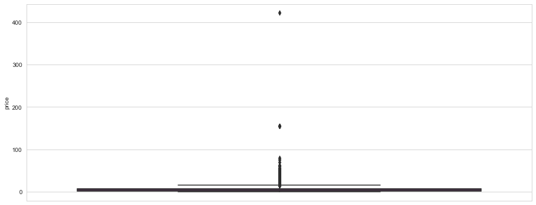

```python
ax =sns.boxplot(data=df_all, y='price')
ax.figure.set_size_inches(15,6)
```

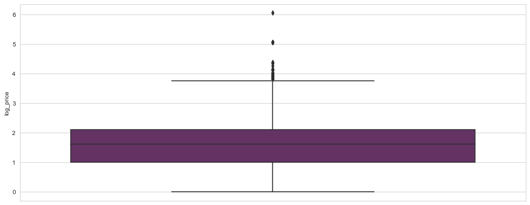

```python
ax =sns.boxplot(data=df_all, y='log_price')
ax.figure.set_size_inches(15,6)
```

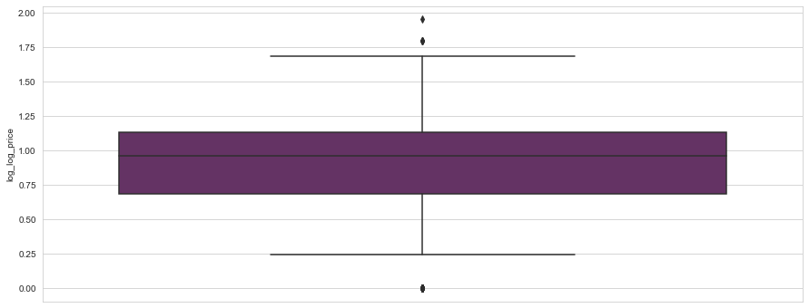

```python
ax =sns.boxplot(data=df_all, y='log_log_price')
ax.figure.set_size_inches(15,6)
```

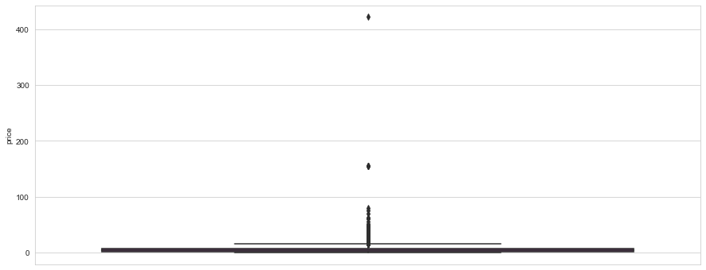

```python
ax = sns.boxplot(data=df_min, y='price')
ax.figure.set_size_inches(15,6)
```

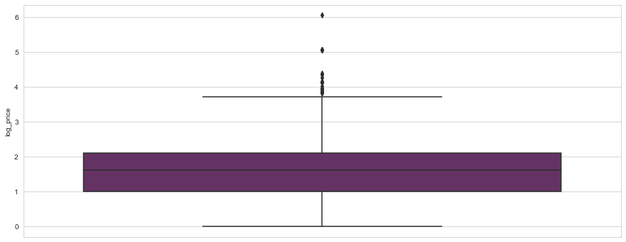

```python
ax = sns.boxplot(data=df_min, y='log_price')
ax.figure.set_size_inches(15,6)
```

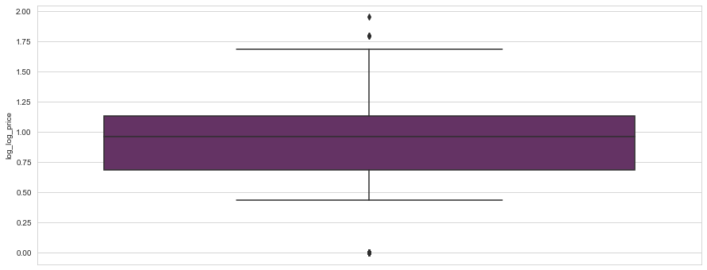

```python
ax = sns.boxplot(data=df_min, y='log_log_price')
ax.figure.set_size_inches(15,6)
```

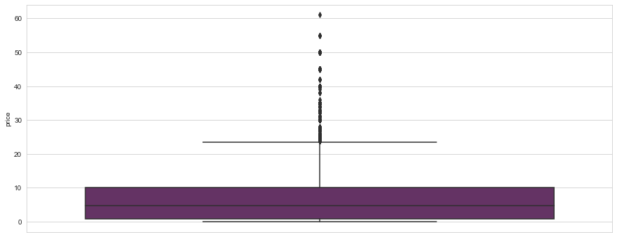

```python
ax = sns.boxplot(data=df_max, y='price')
ax.figure.set_size_inches(15,6)
```

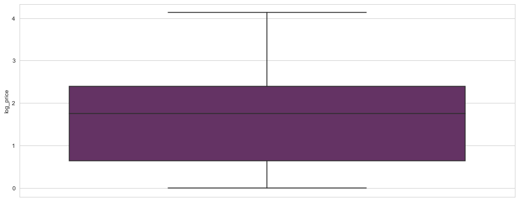

```python
ax = sns.boxplot(data=df_max, y='log_price')
ax.figure.set_size_inches(15,6)
```

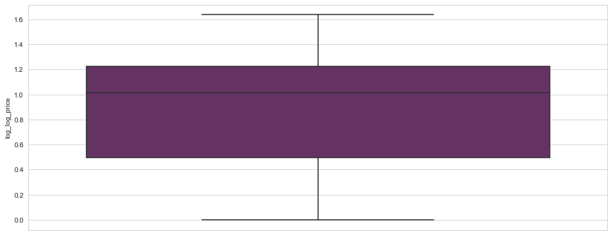

```python
ax = sns.boxplot(data=df_max, y='log_log_price')
ax.figure.set_size_inches(15,6)
```

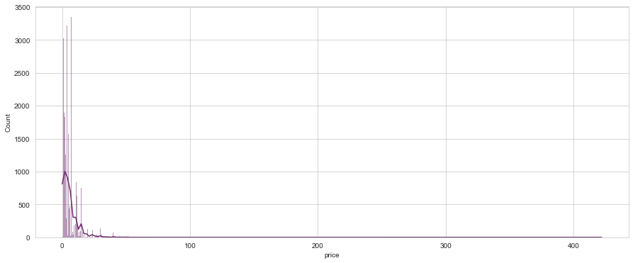

```python
ax = sns.histplot(data=df_all['price'], kde=True)
ax.figure.set_size_inches(15,6)
```

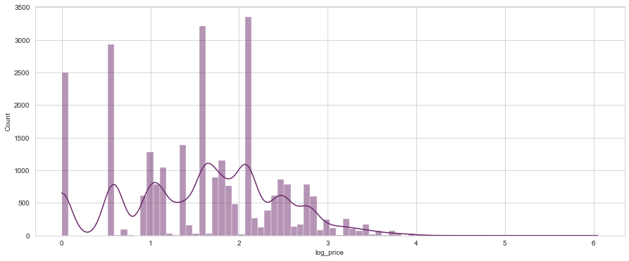

```python
ax = sns.histplot(data=df_all['log_price'], kde=True)
ax.figure.set_size_inches(15,6)
```

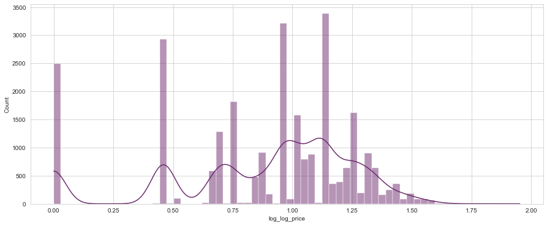

```python
ax = sns.histplot(data=df_all['log_log_price'], kde=True)
ax.figure.set_size_inches(15,6)
```

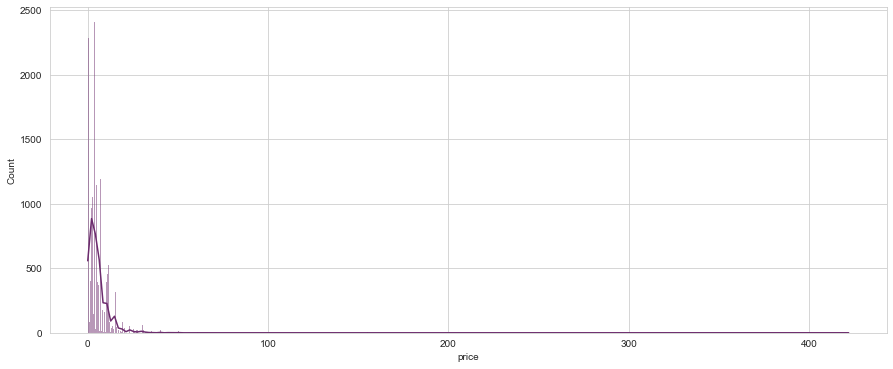

```python
ax = sns.histplot(data=df_min['price'], kde=True)
ax.figure.set_size_inches(15,6)
```

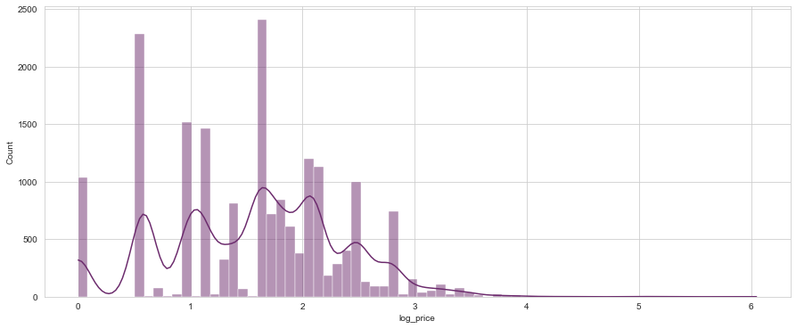

```python
ax = sns.histplot(data=df_min['log_price'], kde=True)
ax.figure.set_size_inches(15,6)
```

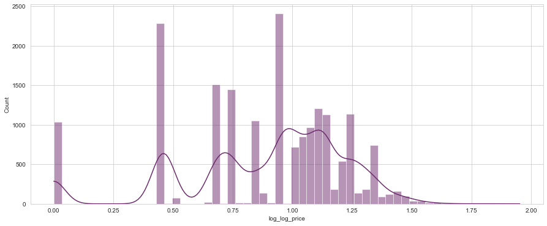

```python
ax = sns.histplot(data=df_min['log_log_price'], kde=True)
ax.figure.set_size_inches(15,6)
```

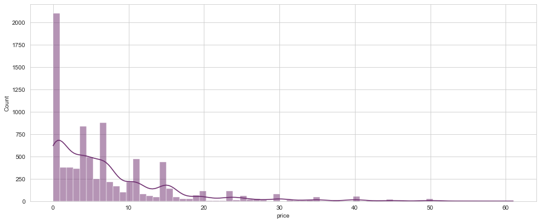

```python
ax = sns.histplot(data=df_max['price'], kde=True)
ax.figure.set_size_inches(15,6)
```

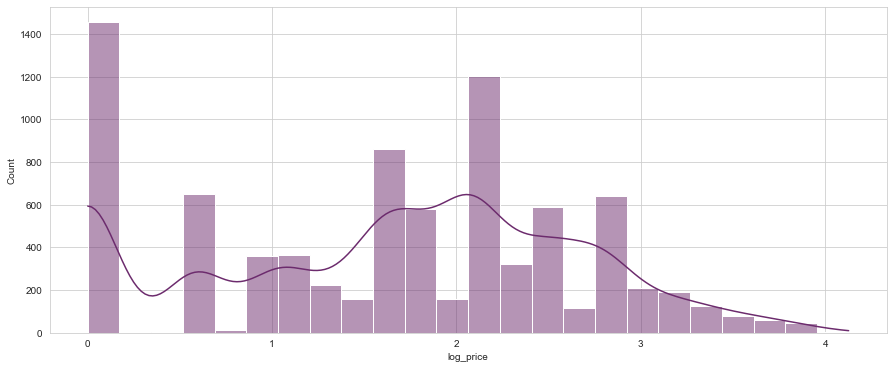

```python
ax = sns.histplot(data=df_max['log_price'], kde=True)
ax.figure.set_size_inches(15,6)
```

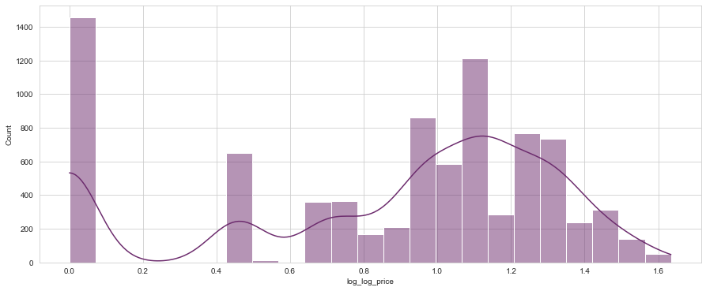

```python
ax = sns.histplot(data=df_max['log_log_price'], kde=True)
ax.figure.set_size_inches(15,6)
```

É perceptível que nenhuma das distribuições de preço segue o formato de uma normal. Poderiamos utilizar um teste mais robusto, mas, só pela distribuição dos histogramas, já sabemos que nenhum dos formatos está próximo.

Como temos muitas variáveis, também fica um pouco difícil de se analisar o impacto de cada variável no preço, separadamente. Por isso, acho que é melhor seguir direto para a regressão linear, e utilizar os dados da própria pra refinar o modelo. Particularmente, prefiro a apresentação dos dados da biblioteca StatsModels, então, primeiro farei os testes nela, e depois construirei o modelo de machine learning com a biblioteca sklearn.  
Também pra não gerar maiores confusões, vou primeiro usar o dataframe com todos os dados, depois com os dados cujo número médio de owners é 10 mil, e por fim, com o número médio de owners diferente de 10 mil.

```python
Colunas_all = Colunas_Tratada.copy()
```

```python
len(Colunas_all)
```

```
55
```

```python
y_all = df_all['price']
```

```python
X_all = sm.add_constant(df_all[Colunas_all])
```

```python
regressão_all = sm.OLS(y_all, X_all).fit()
```

```python
regressão_all.summary()
```

OLS Regression Results

| Dep. Variable: | price | R-squared: | 0.227 |
| --- | --- | --- | --- |
| Model: | OLS | Adj. R-squared: | 0.226 |
| Method: | Least Squares | F-statistic: | 143.4 |
| Date: | Sun, 24 Oct 2021 | Prob (F-statistic): | 0.00 |
| Time: | 13:28:55 | Log-Likelihood: | -87789. |
| No. Observations: | 26846 | AIC: | 1.757e+05 |
| Df Residuals: | 26790 | BIC: | 1.761e+05 |
| Df Model: | 55 |  |  |
| Covariance Type: | nonrobust |  |  |

|  | coef | std err | t | P>\|t\| | [0.025 | 0.975] |
| --- | --- | --- | --- | --- | --- | --- |
| const | -398.4477 | 43.768 | -9.104 | 0.000 | -484.235 | -312.661 |
| Year | 0.1993 | 0.022 | 9.205 | 0.000 | 0.157 | 0.242 |
| english | 0.2238 | 0.291 | 0.769 | 0.442 | -0.346 | 0.794 |
| platforms_windows | 1.0391 | 2.856 | 0.364 | 0.716 | -4.560 | 6.638 |
| platforms_mac | 0.1497 | 0.112 | 1.338 | 0.181 | -0.070 | 0.369 |
| platforms_linux | -0.3864 | 0.129 | -2.988 | 0.003 | -0.640 | -0.133 |
| genres_Action | -0.3861 | 0.088 | -4.373 | 0.000 | -0.559 | -0.213 |
| genres_Free to Play | -6.1307 | 0.184 | -33.382 | 0.000 | -6.491 | -5.771 |
| genres_Strategy | 0.9648 | 0.105 | 9.150 | 0.000 | 0.758 | 1.171 |
| genres_Adventure | 0.4093 | 0.086 | 4.744 | 0.000 | 0.240 | 0.578 |
| genres_Indie | -3.7317 | 0.095 | -39.285 | 0.000 | -3.918 | -3.546 |
| genres_RPG | 0.5923 | 0.113 | 5.252 | 0.000 | 0.371 | 0.813 |
| genres_Casual | -2.1332 | 0.085 | -24.955 | 0.000 | -2.301 | -1.966 |
| genres_Simulation | 1.5896 | 0.105 | 15.085 | 0.000 | 1.383 | 1.796 |
| genres_Racing | -0.2558 | 0.215 | -1.190 | 0.234 | -0.677 | 0.166 |
| genres_Violent | 0.1569 | 0.300 | 0.523 | 0.601 | -0.432 | 0.745 |
| genres_Massively Multiplayer | -1.0994 | 0.361 | -3.049 | 0.002 | -1.806 | -0.393 |
| genres_Nudity | 1.1908 | 0.496 | 2.400 | 0.016 | 0.218 | 2.163 |
| genres_Sports | 1.2100 | 0.193 | 6.259 | 0.000 | 0.831 | 1.589 |
| genres_Early Access | 1.3827 | 0.134 | 10.349 | 0.000 | 1.121 | 1.645 |
| genres_Gore | -0.1369 | 0.369 | -0.370 | 0.711 | -0.861 | 0.587 |
| genres_Sexual Content | 0.9241 | 0.513 | 1.801 | 0.072 | -0.081 | 1.930 |
| categories_Multi-player | 1.3980 | 0.152 | 9.198 | 0.000 | 1.100 | 1.696 |
| categories_Online Multi-Player | 1.8265 | 0.201 | 9.107 | 0.000 | 1.433 | 2.220 |
| categories_Local Multi-Player | 0.0646 | 0.228 | 0.284 | 0.776 | -0.382 | 0.511 |
| categories_Valve Anti-Cheat enabled | 3.1379 | 0.707 | 4.440 | 0.000 | 1.753 | 4.523 |
| categories_Single-player | 1.3099 | 0.224 | 5.848 | 0.000 | 0.871 | 1.749 |
| categories_Steam Cloud | 1.7587 | 0.102 | 17.280 | 0.000 | 1.559 | 1.958 |
| categories_Steam Achievements | 0.6710 | 0.096 | 7.021 | 0.000 | 0.484 | 0.858 |
| categories_Steam Trading Cards | 0.5796 | 0.102 | 5.679 | 0.000 | 0.380 | 0.780 |
| categories_Captions available | 0.0765 | 0.249 | 0.307 | 0.759 | -0.412 | 0.565 |
| categories_Partial Controller Support | 0.9660 | 0.117 | 8.289 | 0.000 | 0.738 | 1.194 |
| categories_Includes Source SDK | -2.8936 | 1.175 | -2.462 | 0.014 | -5.197 | -0.590 |
| categories_Cross-Platform Multiplayer | -1.2881 | 0.229 | -5.613 | 0.000 | -1.738 | -0.838 |
| categories_Stats | -0.6329 | 0.166 | -3.812 | 0.000 | -0.958 | -0.307 |
| categories_Commentary available | -0.4946 | 0.540 | -0.917 | 0.359 | -1.552 | 0.563 |
| categories_Includes level editor | -0.0701 | 0.240 | -0.292 | 0.770 | -0.540 | 0.400 |
| categories_Steam Workshop | 2.1671 | 0.262 | 8.259 | 0.000 | 1.653 | 2.681 |
| categories_In-App Purchases | -1.2810 | 0.293 | -4.378 | 0.000 | -1.855 | -0.708 |
| categories_Co-op | 1.1491 | 0.244 | 4.705 | 0.000 | 0.670 | 1.628 |
| categories_Full controller support | 1.9063 | 0.116 | 16.451 | 0.000 | 1.679 | 2.133 |
| categories_Steam Leaderboards | -0.5609 | 0.132 | -4.238 | 0.000 | -0.820 | -0.302 |
| categories_SteamVR Collectibles | 8.6050 | 1.049 | 8.205 | 0.000 | 6.549 | 10.660 |
| categories_Online Co-op | 0.0803 | 0.308 | 0.261 | 0.794 | -0.523 | 0.684 |
| categories_Shared/Split Screen | -0.1753 | 0.194 | -0.904 | 0.366 | -0.555 | 0.205 |
| categories_Local Co-op | -0.5647 | 0.314 | -1.796 | 0.073 | -1.181 | 0.052 |
| categories_MMO | 0.3569 | 0.454 | 0.785 | 0.432 | -0.534 | 1.248 |
| categories_VR Support | 1.4219 | 0.441 | 3.225 | 0.001 | 0.558 | 2.286 |
| categories_Mods | -1.3181 | 6.512 | -0.202 | 0.840 | -14.082 | 11.446 |
| categories_Mods (require HL2) | -0.6887 | 9.023 | -0.076 | 0.939 | -18.374 | 16.997 |
| categories_Steam Turn Notifications | 1.1034 | 0.816 | 1.353 | 0.176 | -0.495 | 2.702 |
| achievements | 2.375e-06 | 0.000 | 0.021 | 0.983 | -0.000 | 0.000 |
| %_ratings | 1.4823 | 0.174 | 8.504 | 0.000 | 1.141 | 1.824 |
| QTD_ratings | 1.007e-05 | 2.57e-06 | 3.913 | 0.000 | 5.03e-06 | 1.51e-05 |
| owners_mean | -9.834e-08 | 4.51e-08 | -2.180 | 0.029 | -1.87e-07 | -9.92e-09 |
| average_playtime_>0 | 1.0625 | 0.110 | 9.634 | 0.000 | 0.846 | 1.279 |

| Omnibus: | 51073.102 | Durbin-Watson: | 1.908 |
| --- | --- | --- | --- |
| Prob(Omnibus): | 0.000 | Jarque-Bera (JB): | 575051620.740 |
| Skew: | 13.954 | Prob(JB): | 0.00 |
| Kurtosis: | 719.457 | Cond. No. | 1.51e+09 |

Notes:  
[1] Standard Errors assume that the covariance matrix of the errors is correctly specified.  
[2] The condition number is large, 1.51e+09. This might indicate that there are  
strong multicollinearity or other numerical problems.

Rodada a primeira regressão, vemos que os números não foram muito animadores. As variáveis abaixo serão excluidas do modelo, e veremos se temos alguma melhora.

```python
Retirar = ['english',
'platforms_windows',
'platforms_mac',
'genres_Racing',
'genres_Violent',
'genres_Gore',
'genres_Sexual Content',
'categories_Local Multi-Player',
'categories_Captions available',
'categories_Commentary available',
'categories_Includes level editor',
'categories_Online Co-op',
'categories_Shared/Split Screen',
'categories_Local Co-op',
'categories_MMO',
'categories_Mods',
'categories_Mods (require HL2)',
'categories_Steam Turn Notifications',
'achievements']
```

```python
for i in Retirar:
    Colunas_all.remove(i)
```

```python
len(Colunas_all)
```

```
36
```

```python
X_all = sm.add_constant(df_all[Colunas_all])
```

```python
regressão_all = sm.OLS(y_all, X_all).fit()
```

```python
regressão_all.summary()
```

OLS Regression Results

| Dep. Variable: | price | R-squared: | 0.227 |
| --- | --- | --- | --- |
| Model: | OLS | Adj. R-squared: | 0.226 |
| Method: | Least Squares | F-statistic: | 218.6 |
| Date: | Sun, 24 Oct 2021 | Prob (F-statistic): | 0.00 |
| Time: | 13:28:55 | Log-Likelihood: | -87798. |
| No. Observations: | 26846 | AIC: | 1.757e+05 |
| Df Residuals: | 26809 | BIC: | 1.760e+05 |
| Df Model: | 36 |  |  |
| Covariance Type: | nonrobust |  |  |

|  | coef | std err | t | P>\|t\| | [0.025 | 0.975] |
| --- | --- | --- | --- | --- | --- | --- |
| const | -389.9933 | 43.131 | -9.042 | 0.000 | -474.533 | -305.454 |
| Year | 0.1957 | 0.021 | 9.148 | 0.000 | 0.154 | 0.238 |
| platforms_linux | -0.2884 | 0.106 | -2.732 | 0.006 | -0.495 | -0.081 |
| genres_Action | -0.3976 | 0.087 | -4.558 | 0.000 | -0.569 | -0.227 |
| genres_Free to Play | -6.1063 | 0.183 | -33.422 | 0.000 | -6.464 | -5.748 |
| genres_Strategy | 0.9723 | 0.105 | 9.269 | 0.000 | 0.767 | 1.178 |
| genres_Adventure | 0.4258 | 0.086 | 4.975 | 0.000 | 0.258 | 0.594 |
| genres_Indie | -3.7323 | 0.095 | -39.449 | 0.000 | -3.918 | -3.547 |
| genres_RPG | 0.6105 | 0.111 | 5.492 | 0.000 | 0.393 | 0.828 |
| genres_Casual | -2.1394 | 0.085 | -25.234 | 0.000 | -2.306 | -1.973 |
| genres_Simulation | 1.5934 | 0.105 | 15.177 | 0.000 | 1.388 | 1.799 |
| genres_Massively Multiplayer | -0.8851 | 0.285 | -3.104 | 0.002 | -1.444 | -0.326 |
| genres_Nudity | 1.7458 | 0.394 | 4.430 | 0.000 | 0.973 | 2.518 |
| genres_Sports | 1.1259 | 0.187 | 6.009 | 0.000 | 0.759 | 1.493 |
| genres_Early Access | 1.3809 | 0.133 | 10.347 | 0.000 | 1.119 | 1.642 |
| categories_Multi-player | 1.3906 | 0.145 | 9.564 | 0.000 | 1.106 | 1.676 |
| categories_Online Multi-Player | 1.8707 | 0.178 | 10.535 | 0.000 | 1.523 | 2.219 |
| categories_Valve Anti-Cheat enabled | 3.1420 | 0.700 | 4.488 | 0.000 | 1.770 | 4.514 |
| categories_Single-player | 1.3157 | 0.222 | 5.936 | 0.000 | 0.881 | 1.750 |
| categories_Steam Cloud | 1.7538 | 0.101 | 17.298 | 0.000 | 1.555 | 1.953 |
| categories_Steam Achievements | 0.6959 | 0.094 | 7.392 | 0.000 | 0.511 | 0.880 |
| categories_Steam Trading Cards | 0.5861 | 0.102 | 5.755 | 0.000 | 0.386 | 0.786 |
| categories_Partial Controller Support | 0.9309 | 0.115 | 8.085 | 0.000 | 0.705 | 1.157 |
| categories_Includes Source SDK | -3.0793 | 1.136 | -2.712 | 0.007 | -5.305 | -0.854 |
| categories_Cross-Platform Multiplayer | -1.1902 | 0.226 | -5.265 | 0.000 | -1.633 | -0.747 |
| categories_Stats | -0.6367 | 0.165 | -3.848 | 0.000 | -0.961 | -0.312 |
| categories_Steam Workshop | 2.1350 | 0.231 | 9.224 | 0.000 | 1.681 | 2.589 |
| categories_In-App Purchases | -1.2358 | 0.291 | -4.251 | 0.000 | -1.806 | -0.666 |
| categories_Co-op | 0.8958 | 0.151 | 5.935 | 0.000 | 0.600 | 1.192 |
| categories_Full controller support | 1.8488 | 0.113 | 16.425 | 0.000 | 1.628 | 2.069 |
| categories_Steam Leaderboards | -0.5677 | 0.132 | -4.304 | 0.000 | -0.826 | -0.309 |
| categories_SteamVR Collectibles | 8.6575 | 1.048 | 8.261 | 0.000 | 6.603 | 10.712 |
| categories_VR Support | 1.4336 | 0.440 | 3.255 | 0.001 | 0.570 | 2.297 |
| %_ratings | 1.4765 | 0.173 | 8.513 | 0.000 | 1.137 | 1.816 |
| QTD_ratings | 1.005e-05 | 2.57e-06 | 3.908 | 0.000 | 5.01e-06 | 1.51e-05 |
| owners_mean | -9.592e-08 | 4.5e-08 | -2.131 | 0.033 | -1.84e-07 | -7.69e-09 |
| average_playtime_>0 | 1.0790 | 0.110 | 9.802 | 0.000 | 0.863 | 1.295 |

| Omnibus: | 51057.600 | Durbin-Watson: | 1.908 |
| --- | --- | --- | --- |
| Prob(Omnibus): | 0.000 | Jarque-Bera (JB): | 573664514.219 |
| Skew: | 13.945 | Prob(JB): | 0.00 |
| Kurtosis: | 718.592 | Cond. No. | 1.49e+09 |

Notes:  
[1] Standard Errors assume that the covariance matrix of the errors is correctly specified.  
[2] The condition number is large, 1.49e+09. This might indicate that there are  
strong multicollinearity or other numerical problems.

O baixo valor de R² indica que, de fato, essas variáveis sou pouco eficientes para explicar o preço dos jogos. Vou tentar fazer esses mesmos cálculos para log_price e log_log_price.

```python
Colunas_all = Colunas_Tratada.copy()
```

```python
len(Colunas_all)
```

```
55
```

```python
y_all = df_all['log_price']
X_all = sm.add_constant(df_all[Colunas_all])
regressão_all = sm.OLS(y_all, X_all).fit()
regressão_all.summary()
```

OLS Regression Results

| Dep. Variable: | log_price | R-squared: | 0.402 |
| --- | --- | --- | --- |
| Model: | OLS | Adj. R-squared: | 0.401 |
| Method: | Least Squares | F-statistic: | 327.5 |
| Date: | Sun, 24 Oct 2021 | Prob (F-statistic): | 0.00 |
| Time: | 13:28:55 | Log-Likelihood: | -27270. |
| No. Observations: | 26846 | AIC: | 5.465e+04 |
| Df Residuals: | 26790 | BIC: | 5.511e+04 |
| Df Model: | 55 |  |  |
| Covariance Type: | nonrobust |  |  |

|  | coef | std err | t | P>\|t\| | [0.025 | 0.975] |
| --- | --- | --- | --- | --- | --- | --- |
| const | 31.4903 | 4.593 | 6.856 | 0.000 | 22.487 | 40.493 |
| Year | -0.0151 | 0.002 | -6.657 | 0.000 | -0.020 | -0.011 |
| english | 0.1190 | 0.031 | 3.898 | 0.000 | 0.059 | 0.179 |
| platforms_windows | 0.2571 | 0.300 | 0.858 | 0.391 | -0.330 | 0.845 |
| platforms_mac | 0.0959 | 0.012 | 8.173 | 0.000 | 0.073 | 0.119 |
| platforms_linux | -0.0572 | 0.014 | -4.211 | 0.000 | -0.084 | -0.031 |
| genres_Action | -0.0174 | 0.009 | -1.872 | 0.061 | -0.036 | 0.001 |
| genres_Free to Play | -1.5431 | 0.019 | -80.062 | 0.000 | -1.581 | -1.505 |
| genres_Strategy | 0.1629 | 0.011 | 14.719 | 0.000 | 0.141 | 0.185 |
| genres_Adventure | 0.1056 | 0.009 | 11.668 | 0.000 | 0.088 | 0.123 |
| genres_Indie | -0.3806 | 0.010 | -38.175 | 0.000 | -0.400 | -0.361 |
| genres_RPG | 0.0889 | 0.012 | 7.509 | 0.000 | 0.066 | 0.112 |
| genres_Casual | -0.2525 | 0.009 | -28.148 | 0.000 | -0.270 | -0.235 |
| genres_Simulation | 0.1882 | 0.011 | 17.018 | 0.000 | 0.167 | 0.210 |
| genres_Racing | -0.0223 | 0.023 | -0.989 | 0.322 | -0.067 | 0.022 |
| genres_Violent | 0.0463 | 0.032 | 1.469 | 0.142 | -0.015 | 0.108 |
| genres_Massively Multiplayer | -0.1053 | 0.038 | -2.783 | 0.005 | -0.179 | -0.031 |
| genres_Nudity | 0.1440 | 0.052 | 2.765 | 0.006 | 0.042 | 0.246 |
| genres_Sports | 0.1560 | 0.020 | 7.691 | 0.000 | 0.116 | 0.196 |
| genres_Early Access | 0.2744 | 0.014 | 19.570 | 0.000 | 0.247 | 0.302 |
| genres_Gore | -0.0612 | 0.039 | -1.578 | 0.115 | -0.137 | 0.015 |
| genres_Sexual Content | 0.1221 | 0.054 | 2.268 | 0.023 | 0.017 | 0.228 |
| categories_Multi-player | 0.1231 | 0.016 | 7.719 | 0.000 | 0.092 | 0.154 |
| categories_Online Multi-Player | 0.1608 | 0.021 | 7.638 | 0.000 | 0.120 | 0.202 |
| categories_Local Multi-Player | 0.0399 | 0.024 | 1.672 | 0.095 | -0.007 | 0.087 |
| categories_Valve Anti-Cheat enabled | 0.1034 | 0.074 | 1.394 | 0.163 | -0.042 | 0.249 |
| categories_Single-player | 0.1271 | 0.024 | 5.405 | 0.000 | 0.081 | 0.173 |
| categories_Steam Cloud | 0.2369 | 0.011 | 22.175 | 0.000 | 0.216 | 0.258 |
| categories_Steam Achievements | 0.0697 | 0.010 | 6.954 | 0.000 | 0.050 | 0.089 |
| categories_Steam Trading Cards | 0.0983 | 0.011 | 9.182 | 0.000 | 0.077 | 0.119 |
| categories_Captions available | 0.0163 | 0.026 | 0.623 | 0.534 | -0.035 | 0.068 |
| categories_Partial Controller Support | 0.1001 | 0.012 | 8.182 | 0.000 | 0.076 | 0.124 |
| categories_Includes Source SDK | -0.2945 | 0.123 | -2.388 | 0.017 | -0.536 | -0.053 |
| categories_Cross-Platform Multiplayer | -0.1068 | 0.024 | -4.435 | 0.000 | -0.154 | -0.060 |
| categories_Stats | -0.0536 | 0.017 | -3.076 | 0.002 | -0.088 | -0.019 |
| categories_Commentary available | -0.0449 | 0.057 | -0.792 | 0.428 | -0.156 | 0.066 |
| categories_Includes level editor | -0.0112 | 0.025 | -0.445 | 0.657 | -0.061 | 0.038 |
| categories_Steam Workshop | 0.2219 | 0.028 | 8.058 | 0.000 | 0.168 | 0.276 |
| categories_In-App Purchases | -0.2507 | 0.031 | -8.165 | 0.000 | -0.311 | -0.191 |
| categories_Co-op | 0.0995 | 0.026 | 3.883 | 0.000 | 0.049 | 0.150 |
| categories_Full controller support | 0.2230 | 0.012 | 18.337 | 0.000 | 0.199 | 0.247 |
| categories_Steam Leaderboards | -0.0313 | 0.014 | -2.255 | 0.024 | -0.059 | -0.004 |
| categories_SteamVR Collectibles | 0.8759 | 0.110 | 7.959 | 0.000 | 0.660 | 1.092 |
| categories_Online Co-op | 0.0267 | 0.032 | 0.827 | 0.408 | -0.037 | 0.090 |
| categories_Shared/Split Screen | 0.0032 | 0.020 | 0.157 | 0.875 | -0.037 | 0.043 |
| categories_Local Co-op | 0.0018 | 0.033 | 0.056 | 0.956 | -0.063 | 0.067 |
| categories_MMO | 0.0206 | 0.048 | 0.431 | 0.666 | -0.073 | 0.114 |
| categories_VR Support | 0.1592 | 0.046 | 3.441 | 0.001 | 0.069 | 0.250 |
| categories_Mods | -0.2117 | 0.683 | -0.310 | 0.757 | -1.551 | 1.128 |
| categories_Mods (require HL2) | -0.0319 | 0.947 | -0.034 | 0.973 | -1.888 | 1.824 |
| categories_Steam Turn Notifications | 0.1267 | 0.086 | 1.480 | 0.139 | -0.041 | 0.294 |
| achievements | -3.837e-06 | 1.17e-05 | -0.327 | 0.744 | -2.68e-05 | 1.92e-05 |
| %_ratings | 0.2417 | 0.018 | 13.211 | 0.000 | 0.206 | 0.278 |
| QTD_ratings | 1.013e-06 | 2.7e-07 | 3.750 | 0.000 | 4.83e-07 | 1.54e-06 |
| owners_mean | -1.419e-08 | 4.73e-09 | -2.998 | 0.003 | -2.35e-08 | -4.92e-09 |
| average_playtime_>0 | -0.0027 | 0.012 | -0.229 | 0.819 | -0.025 | 0.020 |

| Omnibus: | 377.283 | Durbin-Watson: | 1.867 |
| --- | --- | --- | --- |
| Prob(Omnibus): | 0.000 | Jarque-Bera (JB): | 532.838 |
| Skew: | -0.177 | Prob(JB): | 1.98e-116 |
| Kurtosis: | 3.592 | Cond. No. | 1.51e+09 |

Notes:  
[1] Standard Errors assume that the covariance matrix of the errors is correctly specified.  
[2] The condition number is large, 1.51e+09. This might indicate that there are  
strong multicollinearity or other numerical problems.

```python
Retirar = ['platforms_windows',
            'genres_Action',
            'genres_Racing',
            'genres_Violent',
            'genres_Gore',
            'categories_Local Multi-Player',
            'categories_Valve Anti-Cheat enabled',
            'categories_Captions available',
            'categories_Commentary available',
            'categories_Includes level editor',
            'categories_Online Co-op',
            'categories_Shared/Split Screen',
            'categories_Local Co-op',
            'categories_MMO',
            'categories_Mods',
            'categories_Mods (require HL2)',
            'categories_Steam Turn Notifications',
            'achievements',
            'average_playtime_>0']
```

```python
for i in Retirar:
    Colunas_all.remove(i)
```

```python
len(Colunas_all)
```

```
36
```

```python
y_all = df_all['log_price']
X_all = sm.add_constant(df_all[Colunas_all])
regressão_all = sm.OLS(y_all, X_all).fit()
regressão_all.summary()
```

OLS Regression Results

| Dep. Variable: | log_price | R-squared: | 0.402 |
| --- | --- | --- | --- |
| Model: | OLS | Adj. R-squared: | 0.401 |
| Method: | Least Squares | F-statistic: | 499.9 |
| Date: | Sun, 24 Oct 2021 | Prob (F-statistic): | 0.00 |
| Time: | 13:28:55 | Log-Likelihood: | -27279. |
| No. Observations: | 26846 | AIC: | 5.463e+04 |
| Df Residuals: | 26809 | BIC: | 5.494e+04 |
| Df Model: | 36 |  |  |
| Covariance Type: | nonrobust |  |  |

|  | coef | std err | t | P>\|t\| | [0.025 | 0.975] |
| --- | --- | --- | --- | --- | --- | --- |
| const | 30.6930 | 4.333 | 7.084 | 0.000 | 22.200 | 39.186 |
| Year | -0.0146 | 0.002 | -6.798 | 0.000 | -0.019 | -0.010 |
| english | 0.1165 | 0.030 | 3.823 | 0.000 | 0.057 | 0.176 |
| platforms_mac | 0.0986 | 0.012 | 8.446 | 0.000 | 0.076 | 0.121 |
| platforms_linux | -0.0561 | 0.014 | -4.147 | 0.000 | -0.083 | -0.030 |
| genres_Free to Play | -1.5439 | 0.019 | -81.109 | 0.000 | -1.581 | -1.507 |
| genres_Strategy | 0.1662 | 0.011 | 15.182 | 0.000 | 0.145 | 0.188 |
| genres_Adventure | 0.1050 | 0.009 | 11.680 | 0.000 | 0.087 | 0.123 |
| genres_Indie | -0.3822 | 0.010 | -38.635 | 0.000 | -0.402 | -0.363 |
| genres_RPG | 0.0906 | 0.012 | 7.740 | 0.000 | 0.068 | 0.114 |
| genres_Casual | -0.2490 | 0.009 | -28.280 | 0.000 | -0.266 | -0.232 |
| genres_Simulation | 0.1881 | 0.011 | 17.146 | 0.000 | 0.167 | 0.210 |
| genres_Massively Multiplayer | -0.1029 | 0.030 | -3.440 | 0.001 | -0.162 | -0.044 |
| genres_Nudity | 0.1436 | 0.052 | 2.784 | 0.005 | 0.042 | 0.245 |
| genres_Sports | 0.1556 | 0.020 | 7.916 | 0.000 | 0.117 | 0.194 |
| genres_Early Access | 0.2718 | 0.014 | 19.463 | 0.000 | 0.244 | 0.299 |
| genres_Sexual Content | 0.1276 | 0.054 | 2.374 | 0.018 | 0.022 | 0.233 |
| categories_Multi-player | 0.1280 | 0.015 | 8.403 | 0.000 | 0.098 | 0.158 |
| categories_Online Multi-Player | 0.1699 | 0.019 | 9.119 | 0.000 | 0.133 | 0.206 |
| categories_Single-player | 0.1253 | 0.023 | 5.398 | 0.000 | 0.080 | 0.171 |
| categories_Steam Cloud | 0.2377 | 0.011 | 22.337 | 0.000 | 0.217 | 0.259 |
| categories_Steam Achievements | 0.0696 | 0.010 | 7.024 | 0.000 | 0.050 | 0.089 |
| categories_Steam Trading Cards | 0.0974 | 0.010 | 9.570 | 0.000 | 0.077 | 0.117 |
| categories_Partial Controller Support | 0.0968 | 0.012 | 8.106 | 0.000 | 0.073 | 0.120 |
| categories_Includes Source SDK | -0.2931 | 0.118 | -2.480 | 0.013 | -0.525 | -0.061 |
| categories_Cross-Platform Multiplayer | -0.1066 | 0.024 | -4.467 | 0.000 | -0.153 | -0.060 |
| categories_Stats | -0.0533 | 0.017 | -3.073 | 0.002 | -0.087 | -0.019 |
| categories_Steam Workshop | 0.2171 | 0.024 | 8.971 | 0.000 | 0.170 | 0.265 |
| categories_In-App Purchases | -0.2510 | 0.031 | -8.226 | 0.000 | -0.311 | -0.191 |
| categories_Co-op | 0.1151 | 0.016 | 7.294 | 0.000 | 0.084 | 0.146 |
| categories_Full controller support | 0.2216 | 0.012 | 19.116 | 0.000 | 0.199 | 0.244 |
| categories_Steam Leaderboards | -0.0353 | 0.014 | -2.570 | 0.010 | -0.062 | -0.008 |
| categories_SteamVR Collectibles | 0.8714 | 0.110 | 7.925 | 0.000 | 0.656 | 1.087 |
| categories_VR Support | 0.1592 | 0.046 | 3.444 | 0.001 | 0.069 | 0.250 |
| %_ratings | 0.2451 | 0.018 | 13.476 | 0.000 | 0.209 | 0.281 |
| QTD_ratings | 1.028e-06 | 2.7e-07 | 3.809 | 0.000 | 4.99e-07 | 1.56e-06 |
| owners_mean | -1.382e-08 | 4.67e-09 | -2.957 | 0.003 | -2.3e-08 | -4.66e-09 |

| Omnibus: | 373.288 | Durbin-Watson: | 1.867 |
| --- | --- | --- | --- |
| Prob(Omnibus): | 0.000 | Jarque-Bera (JB): | 523.825 |
| Skew: | -0.178 | Prob(JB): | 1.79e-114 |
| Kurtosis: | 3.585 | Cond. No. | 1.42e+09 |

Notes:  
[1] Standard Errors assume that the covariance matrix of the errors is correctly specified.  
[2] The condition number is large, 1.42e+09. This might indicate that there are  
strong multicollinearity or other numerical problems.

Apesar do valor de R² ter subido, ele ainda indica que as variáveis são pouco explicativas para o modelo. Vamos fazer uma última tentativa usando log_log_price.

```python
Colunas_all = Colunas_Tratada.copy()
len(Colunas_all)
```

```
55
```

```python
y_all = df_all['log_log_price']
X_all = sm.add_constant(df_all[Colunas_all])
regressão_all = sm.OLS(y_all, X_all).fit()
regressão_all.summary()
```

OLS Regression Results

| Dep. Variable: | log_log_price | R-squared: | 0.466 |
| --- | --- | --- | --- |
| Model: | OLS | Adj. R-squared: | 0.465 |
| Method: | Least Squares | F-statistic: | 425.9 |
| Date: | Sun, 24 Oct 2021 | Prob (F-statistic): | 0.00 |
| Time: | 13:28:55 | Log-Likelihood: | -4238.4 |
| No. Observations: | 26846 | AIC: | 8589. |
| Df Residuals: | 26790 | BIC: | 9048. |
| Df Model: | 55 |  |  |
| Covariance Type: | nonrobust |  |  |

|  | coef | std err | t | P>\|t\| | [0.025 | 0.975] |
| --- | --- | --- | --- | --- | --- | --- |
| const | 21.5461 | 1.948 | 11.062 | 0.000 | 17.728 | 25.364 |
| Year | -0.0104 | 0.001 | -10.789 | 0.000 | -0.012 | -0.009 |
| english | 0.0641 | 0.013 | 4.951 | 0.000 | 0.039 | 0.089 |
| platforms_windows | 0.1471 | 0.127 | 1.157 | 0.247 | -0.102 | 0.396 |
| platforms_mac | 0.0462 | 0.005 | 9.282 | 0.000 | 0.036 | 0.056 |
| platforms_linux | -0.0247 | 0.006 | -4.291 | 0.000 | -0.036 | -0.013 |
| genres_Action | 7.322e-05 | 0.004 | 0.019 | 0.985 | -0.008 | 0.008 |
| genres_Free to Play | -0.8592 | 0.008 | -105.134 | 0.000 | -0.875 | -0.843 |
| genres_Strategy | 0.0695 | 0.005 | 14.803 | 0.000 | 0.060 | 0.079 |
| genres_Adventure | 0.0467 | 0.004 | 12.172 | 0.000 | 0.039 | 0.054 |
| genres_Indie | -0.1332 | 0.004 | -31.516 | 0.000 | -0.142 | -0.125 |
| genres_RPG | 0.0358 | 0.005 | 7.137 | 0.000 | 0.026 | 0.046 |
| genres_Casual | -0.0906 | 0.004 | -23.808 | 0.000 | -0.098 | -0.083 |
| genres_Simulation | 0.0697 | 0.005 | 14.860 | 0.000 | 0.060 | 0.079 |
| genres_Racing | -0.0006 | 0.010 | -0.067 | 0.947 | -0.019 | 0.018 |
| genres_Violent | 0.0210 | 0.013 | 1.574 | 0.115 | -0.005 | 0.047 |
| genres_Massively Multiplayer | -0.0271 | 0.016 | -1.687 | 0.092 | -0.059 | 0.004 |
| genres_Nudity | 0.0552 | 0.022 | 2.499 | 0.012 | 0.012 | 0.098 |
| genres_Sports | 0.0595 | 0.009 | 6.910 | 0.000 | 0.043 | 0.076 |
| genres_Early Access | 0.1111 | 0.006 | 18.685 | 0.000 | 0.099 | 0.123 |
| genres_Gore | -0.0263 | 0.016 | -1.600 | 0.110 | -0.059 | 0.006 |
| genres_Sexual Content | 0.0488 | 0.023 | 2.137 | 0.033 | 0.004 | 0.094 |
| categories_Multi-player | 0.0393 | 0.007 | 5.817 | 0.000 | 0.026 | 0.053 |
| categories_Online Multi-Player | 0.0487 | 0.009 | 5.456 | 0.000 | 0.031 | 0.066 |
| categories_Local Multi-Player | 0.0199 | 0.010 | 1.961 | 0.050 | 6.55e-06 | 0.040 |
| categories_Valve Anti-Cheat enabled | 0.0124 | 0.031 | 0.394 | 0.693 | -0.049 | 0.074 |
| categories_Single-player | 0.0549 | 0.010 | 5.510 | 0.000 | 0.035 | 0.074 |
| categories_Steam Cloud | 0.0936 | 0.005 | 20.661 | 0.000 | 0.085 | 0.102 |
| categories_Steam Achievements | 0.0273 | 0.004 | 6.410 | 0.000 | 0.019 | 0.036 |
| categories_Steam Trading Cards | 0.0444 | 0.005 | 9.772 | 0.000 | 0.035 | 0.053 |
| categories_Captions available | 0.0092 | 0.011 | 0.833 | 0.405 | -0.012 | 0.031 |
| categories_Partial Controller Support | 0.0370 | 0.005 | 7.136 | 0.000 | 0.027 | 0.047 |
| categories_Includes Source SDK | -0.1004 | 0.052 | -1.920 | 0.055 | -0.203 | 0.002 |
| categories_Cross-Platform Multiplayer | -0.0372 | 0.010 | -3.647 | 0.000 | -0.057 | -0.017 |
| categories_Stats | -0.0190 | 0.007 | -2.572 | 0.010 | -0.033 | -0.005 |
| categories_Commentary available | -0.0148 | 0.024 | -0.617 | 0.537 | -0.062 | 0.032 |
| categories_Includes level editor | -0.0046 | 0.011 | -0.432 | 0.665 | -0.026 | 0.016 |
| categories_Steam Workshop | 0.0743 | 0.012 | 6.364 | 0.000 | 0.051 | 0.097 |
| categories_In-App Purchases | -0.1205 | 0.013 | -9.253 | 0.000 | -0.146 | -0.095 |
| categories_Co-op | 0.0319 | 0.011 | 2.933 | 0.003 | 0.011 | 0.053 |
| categories_Full controller support | 0.0823 | 0.005 | 15.966 | 0.000 | 0.072 | 0.092 |
| categories_Steam Leaderboards | -0.0067 | 0.006 | -1.141 | 0.254 | -0.018 | 0.005 |
| categories_SteamVR Collectibles | 0.3040 | 0.047 | 6.514 | 0.000 | 0.213 | 0.395 |
| categories_Online Co-op | 0.0142 | 0.014 | 1.034 | 0.301 | -0.013 | 0.041 |
| categories_Shared/Split Screen | 0.0045 | 0.009 | 0.520 | 0.603 | -0.012 | 0.021 |
| categories_Local Co-op | 0.0073 | 0.014 | 0.519 | 0.603 | -0.020 | 0.035 |
| categories_MMO | -0.0006 | 0.020 | -0.029 | 0.977 | -0.040 | 0.039 |
| categories_VR Support | 0.0518 | 0.020 | 2.637 | 0.008 | 0.013 | 0.090 |
| categories_Mods | -0.0800 | 0.290 | -0.276 | 0.782 | -0.648 | 0.488 |
| categories_Mods (require HL2) | -0.0138 | 0.402 | -0.034 | 0.973 | -0.801 | 0.773 |
| categories_Steam Turn Notifications | 0.0491 | 0.036 | 1.354 | 0.176 | -0.022 | 0.120 |
| achievements | -3.65e-06 | 4.98e-06 | -0.734 | 0.463 | -1.34e-05 | 6.1e-06 |
| %_ratings | 0.0888 | 0.008 | 11.451 | 0.000 | 0.074 | 0.104 |
| QTD_ratings | 3.919e-07 | 1.15e-07 | 3.421 | 0.001 | 1.67e-07 | 6.16e-07 |
| owners_mean | -6.079e-09 | 2.01e-09 | -3.028 | 0.002 | -1e-08 | -2.14e-09 |
| average_playtime_>0 | -0.0202 | 0.005 | -4.108 | 0.000 | -0.030 | -0.011 |

| Omnibus: | 4473.999 | Durbin-Watson: | 1.884 |
| --- | --- | --- | --- |
| Prob(Omnibus): | 0.000 | Jarque-Bera (JB): | 9342.587 |
| Skew: | -0.998 | Prob(JB): | 0.00 |
| Kurtosis: | 5.090 | Cond. No. | 1.51e+09 |

Notes:  
[1] Standard Errors assume that the covariance matrix of the errors is correctly specified.  
[2] The condition number is large, 1.51e+09. This might indicate that there are  
strong multicollinearity or other numerical problems.

```python
Retirar = ['platforms_windows',
'genres_Action',
'genres_Racing',
'genres_Violent',
'genres_Massively Multiplayer',
'genres_Gore',
'categories_Local Multi-Player',
'categories_Valve Anti-Cheat enabled',
'categories_Captions available',
'categories_Commentary available',
'categories_Includes level editor',
'categories_Includes Source SDK',
'categories_Steam Leaderboards',
'categories_Online Co-op',
'categories_Shared/Split Screen',
'categories_Local Co-op',
'categories_MMO',
'categories_Mods',
'categories_Mods (require HL2)',
'categories_Steam Turn Notifications',
'achievements']
```

```python
for i in Retirar:
    Colunas_all.remove(i)
```

```python
len(Colunas_all)
```

```
34
```

```python
y_all = df_all['log_log_price']
X_all = sm.add_constant(df_all[Colunas_all])
regressão_all = sm.OLS(y_all, X_all).fit()
regressão_all.summary()
```

OLS Regression Results

| Dep. Variable: | log_log_price | R-squared: | 0.466 |
| --- | --- | --- | --- |
| Model: | OLS | Adj. R-squared: | 0.465 |
| Method: | Least Squares | F-statistic: | 687.9 |
| Date: | Sun, 24 Oct 2021 | Prob (F-statistic): | 0.00 |
| Time: | 13:28:56 | Log-Likelihood: | -4253.0 |
| No. Observations: | 26846 | AIC: | 8576. |
| Df Residuals: | 26811 | BIC: | 8863. |
| Df Model: | 34 |  |  |
| Covariance Type: | nonrobust |  |  |

|  | coef | std err | t | P>\|t\| | [0.025 | 0.975] |
| --- | --- | --- | --- | --- | --- | --- |
| const | 20.9406 | 1.921 | 10.901 | 0.000 | 17.176 | 24.706 |
| Year | -0.0100 | 0.001 | -10.526 | 0.000 | -0.012 | -0.008 |
| english | 0.0646 | 0.013 | 4.999 | 0.000 | 0.039 | 0.090 |
| platforms_mac | 0.0471 | 0.005 | 9.518 | 0.000 | 0.037 | 0.057 |
| platforms_linux | -0.0246 | 0.006 | -4.286 | 0.000 | -0.036 | -0.013 |
| genres_Free to Play | -0.8632 | 0.008 | -107.002 | 0.000 | -0.879 | -0.847 |
| genres_Strategy | 0.0699 | 0.005 | 15.061 | 0.000 | 0.061 | 0.079 |
| genres_Adventure | 0.0463 | 0.004 | 12.255 | 0.000 | 0.039 | 0.054 |
| genres_Indie | -0.1329 | 0.004 | -31.688 | 0.000 | -0.141 | -0.125 |
| genres_RPG | 0.0349 | 0.005 | 7.068 | 0.000 | 0.025 | 0.045 |
| genres_Casual | -0.0902 | 0.004 | -24.155 | 0.000 | -0.098 | -0.083 |
| genres_Simulation | 0.0686 | 0.005 | 14.753 | 0.000 | 0.059 | 0.078 |
| genres_Nudity | 0.0561 | 0.022 | 2.565 | 0.010 | 0.013 | 0.099 |
| genres_Sports | 0.0610 | 0.008 | 7.328 | 0.000 | 0.045 | 0.077 |
| genres_Early Access | 0.1106 | 0.006 | 18.681 | 0.000 | 0.099 | 0.122 |
| genres_Sexual Content | 0.0503 | 0.023 | 2.208 | 0.027 | 0.006 | 0.095 |
| categories_Multi-player | 0.0414 | 0.006 | 6.407 | 0.000 | 0.029 | 0.054 |
| categories_Online Multi-Player | 0.0518 | 0.008 | 6.610 | 0.000 | 0.036 | 0.067 |
| categories_Single-player | 0.0608 | 0.009 | 6.442 | 0.000 | 0.042 | 0.079 |
| categories_Steam Cloud | 0.0937 | 0.004 | 20.839 | 0.000 | 0.085 | 0.103 |
| categories_Steam Achievements | 0.0255 | 0.004 | 6.135 | 0.000 | 0.017 | 0.034 |
| categories_Steam Trading Cards | 0.0448 | 0.005 | 9.879 | 0.000 | 0.036 | 0.054 |
| categories_Partial Controller Support | 0.0381 | 0.005 | 7.527 | 0.000 | 0.028 | 0.048 |
| categories_Cross-Platform Multiplayer | -0.0389 | 0.010 | -3.848 | 0.000 | -0.059 | -0.019 |
| categories_Stats | -0.0211 | 0.007 | -2.965 | 0.003 | -0.035 | -0.007 |
| categories_Steam Workshop | 0.0709 | 0.010 | 6.908 | 0.000 | 0.051 | 0.091 |
| categories_In-App Purchases | -0.1255 | 0.013 | -9.790 | 0.000 | -0.151 | -0.100 |
| categories_Co-op | 0.0432 | 0.007 | 6.460 | 0.000 | 0.030 | 0.056 |
| categories_Full controller support | 0.0851 | 0.005 | 17.417 | 0.000 | 0.076 | 0.095 |
| categories_SteamVR Collectibles | 0.3056 | 0.047 | 6.554 | 0.000 | 0.214 | 0.397 |
| categories_VR Support | 0.0496 | 0.020 | 2.529 | 0.011 | 0.011 | 0.088 |
| %_ratings | 0.0899 | 0.008 | 11.662 | 0.000 | 0.075 | 0.105 |
| QTD_ratings | 4.121e-07 | 1.14e-07 | 3.609 | 0.000 | 1.88e-07 | 6.36e-07 |
| owners_mean | -6.508e-09 | 1.98e-09 | -3.295 | 0.001 | -1.04e-08 | -2.64e-09 |
| average_playtime_>0 | -0.0214 | 0.005 | -4.367 | 0.000 | -0.031 | -0.012 |

| Omnibus: | 4469.682 | Durbin-Watson: | 1.884 |
| --- | --- | --- | --- |
| Prob(Omnibus): | 0.000 | Jarque-Bera (JB): | 9292.591 |
| Skew: | -0.999 | Prob(JB): | 0.00 |
| Kurtosis: | 5.077 | Cond. No. | 1.49e+09 |

Notes:  
[1] Standard Errors assume that the covariance matrix of the errors is correctly specified.  
[2] The condition number is large, 1.49e+09. This might indicate that there are  
strong multicollinearity or other numerical problems.

Os números não foram muito animadores. Como o maior valor de R² foi o encontrado na última regressão, vou utiliza-la de base para a análise. Podemos perceber que a variável que tem o maior coeficiente foi 'genres_Free to Play', que se refere ao fato de o jogo ser ou não gratuito para jogar. Podemos assumir que jogos Free to Play possuem um modelo diferente de agariar lucro. Usualmente, são vendidos a preços baixos. Faz sentido o seu coeficiente (beta) ser o maior e negativamente ligado.

```python
regressão_all.params.round(3)
```

```
const                                    20.941
Year                                     -0.010
english                                   0.065
platforms_mac                             0.047
platforms_linux                          -0.025
genres_Free to Play                      -0.863
genres_Strategy                           0.070
genres_Adventure                          0.046
genres_Indie                             -0.133
genres_RPG                                0.035
genres_Casual                            -0.090
genres_Simulation                         0.069
genres_Nudity                             0.056
genres_Sports                             0.061
genres_Early Access                       0.111
genres_Sexual Content                     0.050
categories_Multi-player                   0.041
categories_Online Multi-Player            0.052
categories_Single-player                  0.061
categories_Steam Cloud                    0.094
categories_Steam Achievements             0.025
categories_Steam Trading Cards            0.045
categories_Partial Controller Support     0.038
categories_Cross-Platform Multiplayer    -0.039
categories_Stats                         -0.021
categories_Steam Workshop                 0.071
categories_In-App Purchases              -0.126
categories_Co-op                          0.043
categories_Full controller support        0.085
categories_SteamVR Collectibles           0.306
categories_VR Support                     0.050
%_ratings                                 0.090
QTD_ratings                               0.000
owners_mean                              -0.000
average_playtime_>0                      -0.021
dtype: float64
```

Vamos analisar agora o grupo com média de owners igual a 10 mil.

```python
Colunas_Tratada_min = ['Year','english','platforms_windows','platforms_mac','platforms_linux','genres_Action',
           'genres_Free to Play', 'genres_Strategy','genres_Adventure', 'genres_Indie', 'genres_RPG',
           'genres_Casual','genres_Simulation', 'genres_Racing', 'genres_Violent','genres_Massively Multiplayer',
           'genres_Nudity', 'genres_Sports',       'genres_Early Access', 'genres_Gore', 'genres_Sexual Content',
           'categories_Multi-player', 'categories_Online Multi-Player','categories_Local Multi-Player',
           'categories_Valve Anti-Cheat enabled','categories_Single-player', 'categories_Steam Cloud',
           'categories_Steam Achievements', 'categories_Steam Trading Cards','categories_Captions available',
           'categories_Partial Controller Support','categories_Includes Source SDK','categories_Cross-Platform Multiplayer',
           'categories_Stats','categories_Commentary available', 'categories_Includes level editor',
           'categories_Steam Workshop', 'categories_In-App Purchases','categories_Co-op',
           'categories_Full controller support','categories_Steam Leaderboards', 'categories_SteamVR Collectibles',
           'categories_Online Co-op', 'categories_Shared/Split Screen','categories_Local Co-op', 'categories_MMO',
           'categories_VR Support','categories_Mods', 'categories_Mods (require HL2)',
           'categories_Steam Turn Notifications','achievements','%_ratings','QTD_ratings',
           'average_playtime_>0']
```

```python
Colunas_min = Colunas_Tratada_min.copy()
```

```python
len(Colunas_min)
```

```
54
```

```python
y_min = df_min['price']
X_min = sm.add_constant(df_min[Colunas_min])
regressão_min = sm.OLS(y_min, X_min).fit()
regressão_min.summary()
```

OLS Regression Results

| Dep. Variable: | price | R-squared: | 0.166 |
| --- | --- | --- | --- |
| Model: | OLS | Adj. R-squared: | 0.164 |
| Method: | Least Squares | F-statistic: | 71.64 |
| Date: | Sun, 24 Oct 2021 | Prob (F-statistic): | 0.00 |
| Time: | 13:28:56 | Log-Likelihood: | -59711. |
| No. Observations: | 18433 | AIC: | 1.195e+05 |
| Df Residuals: | 18381 | BIC: | 1.199e+05 |
| Df Model: | 51 |  |  |
| Covariance Type: | nonrobust |  |  |

|  | coef | std err | t | P>\|t\| | [0.025 | 0.975] |
| --- | --- | --- | --- | --- | --- | --- |
| const | -311.8648 | 72.437 | -4.305 | 0.000 | -453.848 | -169.881 |
| Year | 0.1557 | 0.036 | 4.339 | 0.000 | 0.085 | 0.226 |
| english | 0.4209 | 0.310 | 1.357 | 0.175 | -0.187 | 1.029 |
| platforms_windows | 1.9260 | 3.095 | 0.622 | 0.534 | -4.141 | 7.993 |
| platforms_mac | 0.1136 | 0.132 | 0.862 | 0.389 | -0.145 | 0.372 |
| platforms_linux | -0.5594 | 0.158 | -3.551 | 0.000 | -0.868 | -0.251 |
| genres_Action | -0.2527 | 0.103 | -2.458 | 0.014 | -0.454 | -0.051 |
| genres_Free to Play | -5.0359 | 0.289 | -17.441 | 0.000 | -5.602 | -4.470 |
| genres_Strategy | 0.9118 | 0.125 | 7.296 | 0.000 | 0.667 | 1.157 |
| genres_Adventure | 0.4790 | 0.101 | 4.767 | 0.000 | 0.282 | 0.676 |
| genres_Indie | -2.9808 | 0.114 | -26.218 | 0.000 | -3.204 | -2.758 |
| genres_RPG | 0.1408 | 0.138 | 1.022 | 0.307 | -0.129 | 0.411 |
| genres_Casual | -1.6170 | 0.097 | -16.642 | 0.000 | -1.807 | -1.427 |
| genres_Simulation | 1.1744 | 0.122 | 9.625 | 0.000 | 0.935 | 1.414 |
| genres_Racing | -0.2796 | 0.250 | -1.117 | 0.264 | -0.770 | 0.211 |
| genres_Violent | -0.0032 | 0.323 | -0.010 | 0.992 | -0.637 | 0.631 |
| genres_Massively Multiplayer | -1.2348 | 0.458 | -2.696 | 0.007 | -2.133 | -0.337 |
| genres_Nudity | 0.7567 | 0.571 | 1.325 | 0.185 | -0.362 | 1.876 |
| genres_Sports | 1.2458 | 0.214 | 5.826 | 0.000 | 0.827 | 1.665 |
| genres_Early Access | 1.3856 | 0.143 | 9.700 | 0.000 | 1.106 | 1.666 |
| genres_Gore | 0.0050 | 0.402 | 0.012 | 0.990 | -0.783 | 0.793 |
| genres_Sexual Content | 0.6300 | 0.585 | 1.078 | 0.281 | -0.516 | 1.776 |
| categories_Multi-player | 1.4576 | 0.208 | 6.998 | 0.000 | 1.049 | 1.866 |
| categories_Online Multi-Player | 1.1737 | 0.251 | 4.669 | 0.000 | 0.681 | 1.666 |
| categories_Local Multi-Player | 0.2564 | 0.263 | 0.974 | 0.330 | -0.260 | 0.772 |
| categories_Valve Anti-Cheat enabled | -4.454e-12 | 4.4e-12 | -1.011 | 0.312 | -1.31e-11 | 4.18e-12 |
| categories_Single-player | 1.3736 | 0.281 | 4.880 | 0.000 | 0.822 | 1.925 |
| categories_Steam Cloud | 1.2682 | 0.124 | 10.195 | 0.000 | 1.024 | 1.512 |
| categories_Steam Achievements | 0.1300 | 0.110 | 1.182 | 0.237 | -0.086 | 0.346 |
| categories_Steam Trading Cards | 0.7725 | 0.137 | 5.658 | 0.000 | 0.505 | 1.040 |
| categories_Captions available | -0.3222 | 0.314 | -1.025 | 0.305 | -0.938 | 0.294 |
| categories_Partial Controller Support | 0.5106 | 0.139 | 3.665 | 0.000 | 0.238 | 0.784 |
| categories_Includes Source SDK | -2.5364 | 2.350 | -1.079 | 0.281 | -7.143 | 2.070 |
| categories_Cross-Platform Multiplayer | -0.9633 | 0.316 | -3.046 | 0.002 | -1.583 | -0.343 |
| categories_Stats | -0.1566 | 0.203 | -0.771 | 0.441 | -0.555 | 0.241 |
| categories_Commentary available | -1.7112 | 0.786 | -2.178 | 0.029 | -3.251 | -0.171 |
| categories_Includes level editor | 0.5018 | 0.313 | 1.601 | 0.109 | -0.112 | 1.116 |
| categories_Steam Workshop | 0.5315 | 0.377 | 1.409 | 0.159 | -0.208 | 1.271 |
| categories_In-App Purchases | -1.4337 | 0.496 | -2.892 | 0.004 | -2.406 | -0.462 |
| categories_Co-op | 0.2049 | 0.379 | 0.541 | 0.588 | -0.537 | 0.947 |
| categories_Full controller support | 1.0400 | 0.137 | 7.585 | 0.000 | 0.771 | 1.309 |
| categories_Steam Leaderboards | -0.4202 | 0.161 | -2.605 | 0.009 | -0.736 | -0.104 |
| categories_SteamVR Collectibles | 5.2839 | 1.795 | 2.944 | 0.003 | 1.766 | 8.802 |
| categories_Online Co-op | 0.2065 | 0.426 | 0.485 | 0.628 | -0.629 | 1.042 |
| categories_Shared/Split Screen | -0.0623 | 0.245 | -0.254 | 0.799 | -0.543 | 0.418 |
| categories_Local Co-op | 0.4431 | 0.420 | 1.056 | 0.291 | -0.380 | 1.266 |
| categories_MMO | 1.4430 | 0.695 | 2.076 | 0.038 | 0.080 | 2.806 |
| categories_VR Support | 1.2317 | 0.577 | 2.136 | 0.033 | 0.102 | 2.362 |
| categories_Mods | 3.73e-15 | 3.54e-15 | 1.053 | 0.292 | -3.21e-15 | 1.07e-14 |
| categories_Mods (require HL2) | -1.527e-15 | 1.2e-15 | -1.276 | 0.202 | -3.87e-15 | 8.19e-16 |
| categories_Steam Turn Notifications | 0.4714 | 1.021 | 0.462 | 0.644 | -1.530 | 2.473 |
| achievements | 7.605e-05 | 0.000 | 0.624 | 0.533 | -0.000 | 0.000 |
| %_ratings | 0.6842 | 0.188 | 3.645 | 0.000 | 0.316 | 1.052 |
| QTD_ratings | 0.0168 | 0.001 | 24.143 | 0.000 | 0.015 | 0.018 |
| average_playtime_>0 | -0.7861 | 0.237 | -3.322 | 0.001 | -1.250 | -0.322 |

| Omnibus: | 42026.115 | Durbin-Watson: | 1.973 |
| --- | --- | --- | --- |
| Prob(Omnibus): | 0.000 | Jarque-Bera (JB): | 1094610824.774 |
| Skew: | 21.328 | Prob(JB): | 0.00 |
| Kurtosis: | 1196.054 | Cond. No. | 1.00e+16 |

Notes:  
[1] Standard Errors assume that the covariance matrix of the errors is correctly specified.  
[2] The smallest eigenvalue is 7.5e-22. This might indicate that there are  
strong multicollinearity problems or that the design matrix is singular.

```python
y_min = df_min['log_price']
X_min = sm.add_constant(df_min[Colunas_min])
regressão_min = sm.OLS(y_min, X_min).fit()
regressão_min.summary()
```

OLS Regression Results

| Dep. Variable: | log_price | R-squared: | 0.298 |
| --- | --- | --- | --- |
| Model: | OLS | Adj. R-squared: | 0.296 |
| Method: | Least Squares | F-statistic: | 153.0 |
| Date: | Sun, 24 Oct 2021 | Prob (F-statistic): | 0.00 |
| Time: | 13:28:56 | Log-Likelihood: | -18279. |
| No. Observations: | 18433 | AIC: | 3.666e+04 |
| Df Residuals: | 18381 | BIC: | 3.707e+04 |
| Df Model: | 51 |  |  |
| Covariance Type: | nonrobust |  |  |

|  | coef | std err | t | P>\|t\| | [0.025 | 0.975] |
| --- | --- | --- | --- | --- | --- | --- |
| const | 29.1218 | 7.652 | 3.806 | 0.000 | 14.123 | 44.121 |
| Year | -0.0141 | 0.004 | -3.714 | 0.000 | -0.022 | -0.007 |
| english | 0.1477 | 0.033 | 4.505 | 0.000 | 0.083 | 0.212 |
| platforms_windows | 0.4629 | 0.327 | 1.416 | 0.157 | -0.178 | 1.104 |
| platforms_mac | 0.0914 | 0.014 | 6.560 | 0.000 | 0.064 | 0.119 |
| platforms_linux | -0.0815 | 0.017 | -4.899 | 0.000 | -0.114 | -0.049 |
| genres_Action | -0.0033 | 0.011 | -0.304 | 0.761 | -0.025 | 0.018 |
| genres_Free to Play | -1.4173 | 0.031 | -46.464 | 0.000 | -1.477 | -1.358 |
| genres_Strategy | 0.1658 | 0.013 | 12.555 | 0.000 | 0.140 | 0.192 |
| genres_Adventure | 0.1127 | 0.011 | 10.614 | 0.000 | 0.092 | 0.134 |
| genres_Indie | -0.3475 | 0.012 | -28.937 | 0.000 | -0.371 | -0.324 |
| genres_RPG | 0.0462 | 0.015 | 3.174 | 0.002 | 0.018 | 0.075 |
| genres_Casual | -0.2047 | 0.010 | -19.942 | 0.000 | -0.225 | -0.185 |
| genres_Simulation | 0.1361 | 0.013 | 10.561 | 0.000 | 0.111 | 0.161 |
| genres_Racing | -0.0151 | 0.026 | -0.570 | 0.569 | -0.067 | 0.037 |
| genres_Violent | 0.0577 | 0.034 | 1.688 | 0.091 | -0.009 | 0.125 |
| genres_Massively Multiplayer | -0.1543 | 0.048 | -3.188 | 0.001 | -0.249 | -0.059 |
| genres_Nudity | 0.1155 | 0.060 | 1.914 | 0.056 | -0.003 | 0.234 |
| genres_Sports | 0.1677 | 0.023 | 7.426 | 0.000 | 0.123 | 0.212 |
| genres_Early Access | 0.2748 | 0.015 | 18.209 | 0.000 | 0.245 | 0.304 |
| genres_Gore | -0.0662 | 0.042 | -1.559 | 0.119 | -0.149 | 0.017 |
| genres_Sexual Content | 0.0845 | 0.062 | 1.368 | 0.171 | -0.037 | 0.206 |
| categories_Multi-player | 0.1465 | 0.022 | 6.657 | 0.000 | 0.103 | 0.190 |
| categories_Online Multi-Player | 0.1020 | 0.027 | 3.841 | 0.000 | 0.050 | 0.154 |
| categories_Local Multi-Player | 0.0564 | 0.028 | 2.027 | 0.043 | 0.002 | 0.111 |
| categories_Valve Anti-Cheat enabled | -4.801e-13 | 4.65e-13 | -1.032 | 0.302 | -1.39e-12 | 4.32e-13 |
| categories_Single-player | 0.1609 | 0.030 | 5.409 | 0.000 | 0.103 | 0.219 |
| categories_Steam Cloud | 0.1990 | 0.013 | 15.147 | 0.000 | 0.173 | 0.225 |
| categories_Steam Achievements | 0.0084 | 0.012 | 0.726 | 0.468 | -0.014 | 0.031 |
| categories_Steam Trading Cards | 0.1523 | 0.014 | 10.558 | 0.000 | 0.124 | 0.181 |
| categories_Captions available | 0.0020 | 0.033 | 0.061 | 0.951 | -0.063 | 0.067 |
| categories_Partial Controller Support | 0.0572 | 0.015 | 3.886 | 0.000 | 0.028 | 0.086 |
| categories_Includes Source SDK | -0.2645 | 0.248 | -1.065 | 0.287 | -0.751 | 0.222 |
| categories_Cross-Platform Multiplayer | -0.0552 | 0.033 | -1.652 | 0.099 | -0.121 | 0.010 |
| categories_Stats | -0.0178 | 0.021 | -0.829 | 0.407 | -0.060 | 0.024 |
| categories_Commentary available | -0.2417 | 0.083 | -2.912 | 0.004 | -0.404 | -0.079 |
| categories_Includes level editor | 0.0288 | 0.033 | 0.870 | 0.384 | -0.036 | 0.094 |
| categories_Steam Workshop | 0.0796 | 0.040 | 1.999 | 0.046 | 0.002 | 0.158 |
| categories_In-App Purchases | -0.3219 | 0.052 | -6.145 | 0.000 | -0.425 | -0.219 |
| categories_Co-op | 0.0313 | 0.040 | 0.783 | 0.434 | -0.047 | 0.110 |
| categories_Full controller support | 0.1514 | 0.014 | 10.456 | 0.000 | 0.123 | 0.180 |
| categories_Steam Leaderboards | -0.0218 | 0.017 | -1.279 | 0.201 | -0.055 | 0.012 |
| categories_SteamVR Collectibles | 0.5682 | 0.190 | 2.997 | 0.003 | 0.197 | 0.940 |
| categories_Online Co-op | 0.0334 | 0.045 | 0.741 | 0.459 | -0.055 | 0.122 |
| categories_Shared/Split Screen | 0.0033 | 0.026 | 0.129 | 0.898 | -0.047 | 0.054 |
| categories_Local Co-op | 0.0813 | 0.044 | 1.833 | 0.067 | -0.006 | 0.168 |
| categories_MMO | 0.1926 | 0.073 | 2.623 | 0.009 | 0.049 | 0.337 |
| categories_VR Support | 0.1774 | 0.061 | 2.913 | 0.004 | 0.058 | 0.297 |
| categories_Mods | 4.307e-16 | 3.74e-16 | 1.151 | 0.250 | -3.02e-16 | 1.16e-15 |
| categories_Mods (require HL2) | -1.857e-16 | 1.26e-16 | -1.468 | 0.142 | -4.33e-16 | 6.22e-17 |
| categories_Steam Turn Notifications | 0.0127 | 0.108 | 0.118 | 0.906 | -0.199 | 0.224 |
| achievements | 1.837e-05 | 1.29e-05 | 1.426 | 0.154 | -6.88e-06 | 4.36e-05 |
| %_ratings | 0.1499 | 0.020 | 7.558 | 0.000 | 0.111 | 0.189 |
| QTD_ratings | 0.0016 | 7.35e-05 | 21.691 | 0.000 | 0.001 | 0.002 |
| average_playtime_>0 | -0.1088 | 0.025 | -4.352 | 0.000 | -0.158 | -0.060 |

| Omnibus: | 164.007 | Durbin-Watson: | 1.904 |
| --- | --- | --- | --- |
| Prob(Omnibus): | 0.000 | Jarque-Bera (JB): | 236.478 |
| Skew: | -0.103 | Prob(JB): | 4.46e-52 |
| Kurtosis: | 3.516 | Cond. No. | 1.00e+16 |

Notes:  
[1] Standard Errors assume that the covariance matrix of the errors is correctly specified.  
[2] The smallest eigenvalue is 7.5e-22. This might indicate that there are  
strong multicollinearity problems or that the design matrix is singular.

```python
y_min = df_min['log_log_price']
X_min = sm.add_constant(df_min[Colunas_min])
regressão_min = sm.OLS(y_min, X_min).fit()
regressão_min.summary()
```

OLS Regression Results

| Dep. Variable: | log_log_price | R-squared: | 0.325 |
| --- | --- | --- | --- |
| Model: | OLS | Adj. R-squared: | 0.323 |
| Method: | Least Squares | F-statistic: | 173.6 |
| Date: | Sun, 24 Oct 2021 | Prob (F-statistic): | 0.00 |
| Time: | 13:28:56 | Log-Likelihood: | -2768.2 |
| No. Observations: | 18433 | AIC: | 5640. |
| Df Residuals: | 18381 | BIC: | 6047. |
| Df Model: | 51 |  |  |
| Covariance Type: | nonrobust |  |  |

|  | coef | std err | t | P>\|t\| | [0.025 | 0.975] |
| --- | --- | --- | --- | --- | --- | --- |
| const | 22.2608 | 3.299 | 6.748 | 0.000 | 15.795 | 28.727 |
| Year | -0.0108 | 0.002 | -6.612 | 0.000 | -0.014 | -0.008 |
| english | 0.0731 | 0.014 | 5.171 | 0.000 | 0.045 | 0.101 |
| platforms_windows | 0.2413 | 0.141 | 1.712 | 0.087 | -0.035 | 0.518 |
| platforms_mac | 0.0460 | 0.006 | 7.670 | 0.000 | 0.034 | 0.058 |
| platforms_linux | -0.0341 | 0.007 | -4.759 | 0.000 | -0.048 | -0.020 |
| genres_Action | 0.0047 | 0.005 | 0.997 | 0.319 | -0.005 | 0.014 |
| genres_Free to Play | -0.8084 | 0.013 | -61.477 | 0.000 | -0.834 | -0.783 |
| genres_Strategy | 0.0729 | 0.006 | 12.804 | 0.000 | 0.062 | 0.084 |
| genres_Adventure | 0.0507 | 0.005 | 11.087 | 0.000 | 0.042 | 0.060 |
| genres_Indie | -0.1259 | 0.005 | -24.312 | 0.000 | -0.136 | -0.116 |
| genres_RPG | 0.0220 | 0.006 | 3.510 | 0.000 | 0.010 | 0.034 |
| genres_Casual | -0.0754 | 0.004 | -17.034 | 0.000 | -0.084 | -0.067 |
| genres_Simulation | 0.0513 | 0.006 | 9.229 | 0.000 | 0.040 | 0.062 |
| genres_Racing | 0.0048 | 0.011 | 0.417 | 0.677 | -0.018 | 0.027 |
| genres_Violent | 0.0297 | 0.015 | 2.019 | 0.043 | 0.001 | 0.059 |
| genres_Massively Multiplayer | -0.0445 | 0.021 | -2.135 | 0.033 | -0.085 | -0.004 |
| genres_Nudity | 0.0474 | 0.026 | 1.823 | 0.068 | -0.004 | 0.098 |
| genres_Sports | 0.0651 | 0.010 | 6.683 | 0.000 | 0.046 | 0.084 |
| genres_Early Access | 0.1109 | 0.007 | 17.050 | 0.000 | 0.098 | 0.124 |
| genres_Gore | -0.0311 | 0.018 | -1.699 | 0.089 | -0.067 | 0.005 |
| genres_Sexual Content | 0.0333 | 0.027 | 1.249 | 0.212 | -0.019 | 0.085 |
| categories_Multi-player | 0.0527 | 0.009 | 5.554 | 0.000 | 0.034 | 0.071 |
| categories_Online Multi-Player | 0.0248 | 0.011 | 2.169 | 0.030 | 0.002 | 0.047 |
| categories_Local Multi-Player | 0.0247 | 0.012 | 2.056 | 0.040 | 0.001 | 0.048 |
| categories_Valve Anti-Cheat enabled | -1.334e-13 | 2.01e-13 | -0.665 | 0.506 | -5.27e-13 | 2.6e-13 |
| categories_Single-player | 0.0707 | 0.013 | 5.512 | 0.000 | 0.046 | 0.096 |
| categories_Steam Cloud | 0.0810 | 0.006 | 14.307 | 0.000 | 0.070 | 0.092 |
| categories_Steam Achievements | 0.0058 | 0.005 | 1.161 | 0.246 | -0.004 | 0.016 |
| categories_Steam Trading Cards | 0.0657 | 0.006 | 10.565 | 0.000 | 0.054 | 0.078 |
| categories_Captions available | 0.0104 | 0.014 | 0.724 | 0.469 | -0.018 | 0.038 |
| categories_Partial Controller Support | 0.0225 | 0.006 | 3.552 | 0.000 | 0.010 | 0.035 |
| categories_Includes Source SDK | -0.0708 | 0.107 | -0.661 | 0.508 | -0.281 | 0.139 |
| categories_Cross-Platform Multiplayer | -0.0149 | 0.014 | -1.032 | 0.302 | -0.043 | 0.013 |
| categories_Stats | -0.0076 | 0.009 | -0.816 | 0.414 | -0.026 | 0.011 |
| categories_Commentary available | -0.0919 | 0.036 | -2.569 | 0.010 | -0.162 | -0.022 |
| categories_Includes level editor | 0.0072 | 0.014 | 0.505 | 0.614 | -0.021 | 0.035 |
| categories_Steam Workshop | 0.0249 | 0.017 | 1.450 | 0.147 | -0.009 | 0.059 |
| categories_In-App Purchases | -0.1668 | 0.023 | -7.388 | 0.000 | -0.211 | -0.123 |
| categories_Co-op | 0.0142 | 0.017 | 0.822 | 0.411 | -0.020 | 0.048 |
| categories_Full controller support | 0.0601 | 0.006 | 9.625 | 0.000 | 0.048 | 0.072 |
| categories_Steam Leaderboards | -0.0045 | 0.007 | -0.617 | 0.538 | -0.019 | 0.010 |
| categories_SteamVR Collectibles | 0.1830 | 0.082 | 2.239 | 0.025 | 0.023 | 0.343 |
| categories_Online Co-op | 0.0132 | 0.019 | 0.680 | 0.496 | -0.025 | 0.051 |
| categories_Shared/Split Screen | 0.0019 | 0.011 | 0.174 | 0.862 | -0.020 | 0.024 |
| categories_Local Co-op | 0.0300 | 0.019 | 1.571 | 0.116 | -0.007 | 0.068 |
| categories_MMO | 0.0659 | 0.032 | 2.081 | 0.037 | 0.004 | 0.128 |
| categories_VR Support | 0.0682 | 0.026 | 2.599 | 0.009 | 0.017 | 0.120 |
| categories_Mods | 1.334e-16 | 1.61e-16 | 0.827 | 0.408 | -1.83e-16 | 4.49e-16 |
| categories_Mods (require HL2) | -5.973e-17 | 5.45e-17 | -1.096 | 0.273 | -1.67e-16 | 4.71e-17 |
| categories_Steam Turn Notifications | -0.0005 | 0.046 | -0.010 | 0.992 | -0.092 | 0.091 |
| achievements | 6.589e-06 | 5.55e-06 | 1.187 | 0.235 | -4.29e-06 | 1.75e-05 |
| %_ratings | 0.0594 | 0.009 | 6.951 | 0.000 | 0.043 | 0.076 |
| QTD_ratings | 0.0005 | 3.17e-05 | 16.371 | 0.000 | 0.000 | 0.001 |
| average_playtime_>0 | -0.0433 | 0.011 | -4.015 | 0.000 | -0.064 | -0.022 |

| Omnibus: | 2481.648 | Durbin-Watson: | 1.908 |
| --- | --- | --- | --- |
| Prob(Omnibus): | 0.000 | Jarque-Bera (JB): | 4471.626 |
| Skew: | -0.882 | Prob(JB): | 0.00 |
| Kurtosis: | 4.647 | Cond. No. | 1.00e+16 |

Notes:  
[1] Standard Errors assume that the covariance matrix of the errors is correctly specified.  
[2] The smallest eigenvalue is 7.5e-22. This might indicate that there are  
strong multicollinearity problems or that the design matrix is singular.

```python
regressão_min.params.round(3)
```

```
const                                    22.261
Year                                     -0.011
english                                   0.073
platforms_windows                         0.241
platforms_mac                             0.046
platforms_linux                          -0.034
genres_Action                             0.005
genres_Free to Play                      -0.808
genres_Strategy                           0.073
genres_Adventure                          0.051
genres_Indie                             -0.126
genres_RPG                                0.022
genres_Casual                            -0.075
genres_Simulation                         0.051
genres_Racing                             0.005
genres_Violent                            0.030
genres_Massively Multiplayer             -0.045
genres_Nudity                             0.047
genres_Sports                             0.065
genres_Early Access                       0.111
genres_Gore                              -0.031
genres_Sexual Content                     0.033
categories_Multi-player                   0.053
categories_Online Multi-Player            0.025
categories_Local Multi-Player             0.025
categories_Valve Anti-Cheat enabled      -0.000
categories_Single-player                  0.071
categories_Steam Cloud                    0.081
categories_Steam Achievements             0.006
categories_Steam Trading Cards            0.066
categories_Captions available             0.010
categories_Partial Controller Support     0.023
categories_Includes Source SDK           -0.071
categories_Cross-Platform Multiplayer    -0.015
categories_Stats                         -0.008
categories_Commentary available          -0.092
categories_Includes level editor          0.007
categories_Steam Workshop                 0.025
categories_In-App Purchases              -0.167
categories_Co-op                          0.014
categories_Full controller support        0.060
categories_Steam Leaderboards            -0.005
categories_SteamVR Collectibles           0.183
categories_Online Co-op                   0.013
categories_Shared/Split Screen            0.002
categories_Local Co-op                    0.030
categories_MMO                            0.066
categories_VR Support                     0.068
categories_Mods                           0.000
categories_Mods (require HL2)            -0.000
categories_Steam Turn Notifications      -0.000
achievements                              0.000
%_ratings                                 0.059
QTD_ratings                               0.001
average_playtime_>0                      -0.043
dtype: float64
```

Podemos perceber que, no caso dos jogos com menos de 10 mil owners, os dados tem um potencial de explicação de preço ainda menor. Novamente, temos a variável "free to play" como principal contribuinte, provavelmente seguindo a mesma lógica que já foi elencada acima.

Por fim, vamos analizar o último grupo, com owners maiores que 10 mil em média.

```python
Colunas_Tratada_max = ['Year','english','platforms_windows','platforms_mac','platforms_linux','genres_Action',
           'genres_Free to Play', 'genres_Strategy','genres_Adventure', 'genres_Indie', 'genres_RPG',
           'genres_Casual','genres_Simulation', 'genres_Racing', 'genres_Violent','genres_Massively Multiplayer',
           'genres_Nudity', 'genres_Sports',       'genres_Early Access', 'genres_Gore', 'genres_Sexual Content',
           'categories_Multi-player', 'categories_Online Multi-Player','categories_Local Multi-Player',
           'categories_Valve Anti-Cheat enabled','categories_Single-player', 'categories_Steam Cloud',
           'categories_Steam Achievements', 'categories_Steam Trading Cards','categories_Captions available',
           'categories_Partial Controller Support','categories_Includes Source SDK','categories_Cross-Platform Multiplayer',
           'categories_Stats','categories_Commentary available', 'categories_Includes level editor',
           'categories_Steam Workshop', 'categories_In-App Purchases','categories_Co-op',
           'categories_Full controller support','categories_Steam Leaderboards', 'categories_SteamVR Collectibles',
           'categories_Online Co-op', 'categories_Shared/Split Screen','categories_Local Co-op', 'categories_MMO',
           'categories_VR Support','categories_Mods', 'categories_Mods (require HL2)',
           'categories_Steam Turn Notifications','achievements','%_ratings','QTD_ratings','owners_mean',
           'average_playtime_>0']
```

```python
Colunas_max = Colunas_Tratada_max.copy()
len(Colunas_max)
```

```
55
```

```python
y_max = df_max['price']
X_max = sm.add_constant(df_max[Colunas_max])
regressão_max = sm.OLS(y_max, X_max).fit()
regressão_max.summary()
```

OLS Regression Results

| Dep. Variable: | price | R-squared: | 0.388 |
| --- | --- | --- | --- |
| Model: | OLS | Adj. R-squared: | 0.384 |
| Method: | Least Squares | F-statistic: | 96.33 |
| Date: | Sun, 24 Oct 2021 | Prob (F-statistic): | 0.00 |
| Time: | 13:28:56 | Log-Likelihood: | -27470. |
| No. Observations: | 8413 | AIC: | 5.505e+04 |
| Df Residuals: | 8357 | BIC: | 5.545e+04 |
| Df Model: | 55 |  |  |
| Covariance Type: | nonrobust |  |  |

|  | coef | std err | t | P>\|t\| | [0.025 | 0.975] |
| --- | --- | --- | --- | --- | --- | --- |
| const | -935.5121 | 65.796 | -14.218 | 0.000 | -1064.489 | -806.535 |
| Year | 0.4664 | 0.032 | 14.369 | 0.000 | 0.403 | 0.530 |
| english | 1.0929 | 0.719 | 1.519 | 0.129 | -0.317 | 2.503 |
| platforms_windows | -0.4316 | 6.408 | -0.067 | 0.946 | -12.994 | 12.131 |
| platforms_mac | 0.0030 | 0.199 | 0.015 | 0.988 | -0.387 | 0.393 |
| platforms_linux | -0.0895 | 0.216 | -0.414 | 0.679 | -0.513 | 0.334 |
| genres_Action | -0.5595 | 0.161 | -3.473 | 0.001 | -0.875 | -0.244 |
| genres_Free to Play | -7.7073 | 0.257 | -30.039 | 0.000 | -8.210 | -7.204 |
| genres_Strategy | 1.1245 | 0.186 | 6.055 | 0.000 | 0.760 | 1.489 |
| genres_Adventure | -0.0217 | 0.158 | -0.138 | 0.890 | -0.331 | 0.288 |
| genres_Indie | -4.5956 | 0.166 | -27.752 | 0.000 | -4.920 | -4.271 |
| genres_RPG | 1.0531 | 0.187 | 5.620 | 0.000 | 0.686 | 1.420 |
| genres_Casual | -2.8100 | 0.167 | -16.831 | 0.000 | -3.137 | -2.483 |
| genres_Simulation | 1.4421 | 0.198 | 7.296 | 0.000 | 1.055 | 1.830 |
| genres_Racing | -0.1355 | 0.392 | -0.346 | 0.729 | -0.904 | 0.633 |
| genres_Violent | 0.3475 | 0.695 | 0.500 | 0.617 | -1.016 | 1.711 |
| genres_Massively Multiplayer | -1.1192 | 0.561 | -1.995 | 0.046 | -2.219 | -0.019 |
| genres_Nudity | 1.4402 | 0.927 | 1.553 | 0.120 | -0.378 | 3.258 |
| genres_Sports | 0.9563 | 0.407 | 2.352 | 0.019 | 0.159 | 1.753 |
| genres_Early Access | 1.0763 | 0.330 | 3.266 | 0.001 | 0.430 | 1.722 |
| genres_Gore | -0.4743 | 0.818 | -0.580 | 0.562 | -2.077 | 1.128 |
| genres_Sexual Content | 1.4741 | 0.980 | 1.504 | 0.133 | -0.447 | 3.395 |
| categories_Multi-player | 1.1916 | 0.221 | 5.395 | 0.000 | 0.759 | 1.625 |
| categories_Online Multi-Player | 2.0345 | 0.335 | 6.080 | 0.000 | 1.379 | 2.690 |
| categories_Local Multi-Player | 0.3598 | 0.455 | 0.791 | 0.429 | -0.532 | 1.252 |
| categories_Valve Anti-Cheat enabled | 3.0742 | 0.718 | 4.281 | 0.000 | 1.667 | 4.482 |
| categories_Single-player | 1.0659 | 0.360 | 2.964 | 0.003 | 0.361 | 1.771 |
| categories_Steam Cloud | 1.8655 | 0.170 | 10.988 | 0.000 | 1.533 | 2.198 |
| categories_Steam Achievements | 1.4979 | 0.181 | 8.287 | 0.000 | 1.144 | 1.852 |
| categories_Steam Trading Cards | -0.9873 | 0.169 | -5.847 | 0.000 | -1.318 | -0.656 |
| categories_Captions available | 0.7383 | 0.394 | 1.872 | 0.061 | -0.035 | 1.511 |
| categories_Partial Controller Support | 1.6088 | 0.201 | 7.986 | 0.000 | 1.214 | 2.004 |
| categories_Includes Source SDK | -3.2982 | 1.362 | -2.421 | 0.015 | -5.968 | -0.628 |
| categories_Cross-Platform Multiplayer | -1.4277 | 0.327 | -4.361 | 0.000 | -2.070 | -0.786 |
| categories_Stats | -1.2137 | 0.273 | -4.439 | 0.000 | -1.750 | -0.678 |
| categories_Commentary available | 0.1619 | 0.724 | 0.223 | 0.823 | -1.258 | 1.582 |
| categories_Includes level editor | -0.5101 | 0.360 | -1.417 | 0.156 | -1.216 | 0.195 |
| categories_Steam Workshop | 2.7755 | 0.362 | 7.658 | 0.000 | 2.065 | 3.486 |
| categories_In-App Purchases | -1.1512 | 0.371 | -3.102 | 0.002 | -1.879 | -0.424 |
| categories_Co-op | 1.6304 | 0.320 | 5.098 | 0.000 | 1.003 | 2.257 |
| categories_Full controller support | 2.9007 | 0.206 | 14.060 | 0.000 | 2.496 | 3.305 |
| categories_Steam Leaderboards | -0.7060 | 0.221 | -3.199 | 0.001 | -1.139 | -0.273 |
| categories_SteamVR Collectibles | 8.9334 | 1.296 | 6.893 | 0.000 | 6.393 | 11.474 |
| categories_Online Co-op | -0.2944 | 0.454 | -0.648 | 0.517 | -1.185 | 0.596 |
| categories_Shared/Split Screen | -0.4074 | 0.307 | -1.328 | 0.184 | -1.009 | 0.194 |
| categories_Local Co-op | -0.8173 | 0.553 | -1.477 | 0.140 | -1.902 | 0.267 |
| categories_MMO | 0.0942 | 0.624 | 0.151 | 0.880 | -1.129 | 1.318 |
| categories_VR Support | 0.7735 | 0.664 | 1.165 | 0.244 | -0.528 | 2.075 |
| categories_Mods | 0.8817 | 6.534 | 0.135 | 0.893 | -11.927 | 13.691 |
| categories_Mods (require HL2) | -1.3331 | 9.010 | -0.148 | 0.882 | -18.996 | 16.330 |
| categories_Steam Turn Notifications | 1.7765 | 1.293 | 1.374 | 0.170 | -0.759 | 4.312 |
| achievements | -0.0005 | 0.000 | -2.089 | 0.037 | -0.001 | -3.17e-05 |
| %_ratings | 3.3826 | 0.426 | 7.937 | 0.000 | 2.547 | 4.218 |
| QTD_ratings | 7.736e-06 | 2.58e-06 | 2.998 | 0.003 | 2.68e-06 | 1.28e-05 |
| owners_mean | -7.349e-08 | 4.57e-08 | -1.609 | 0.108 | -1.63e-07 | 1.61e-08 |
| average_playtime_>0 | 0.7185 | 0.154 | 4.658 | 0.000 | 0.416 | 1.021 |

| Omnibus: | 3263.985 | Durbin-Watson: | 1.831 |
| --- | --- | --- | --- |
| Prob(Omnibus): | 0.000 | Jarque-Bera (JB): | 18777.182 |
| Skew: | 1.767 | Prob(JB): | 0.00 |
| Kurtosis: | 9.410 | Cond. No. | 2.27e+09 |

Notes:  
[1] Standard Errors assume that the covariance matrix of the errors is correctly specified.  
[2] The condition number is large, 2.27e+09. This might indicate that there are  
strong multicollinearity or other numerical problems.

```python
y_max = df_max['log_price']
X_max = sm.add_constant(df_max[Colunas_max])
regressão_max = sm.OLS(y_max, X_max).fit()
regressão_max.summary()
```

OLS Regression Results

| Dep. Variable: | log_price | R-squared: | 0.580 |
| --- | --- | --- | --- |
| Model: | OLS | Adj. R-squared: | 0.577 |
| Method: | Least Squares | F-statistic: | 209.5 |
| Date: | Sun, 24 Oct 2021 | Prob (F-statistic): | 0.00 |
| Time: | 13:28:57 | Log-Likelihood: | -8510.5 |
| No. Observations: | 8413 | AIC: | 1.713e+04 |
| Df Residuals: | 8357 | BIC: | 1.753e+04 |
| Df Model: | 55 |  |  |
| Covariance Type: | nonrobust |  |  |

|  | coef | std err | t | P>\|t\| | [0.025 | 0.975] |
| --- | --- | --- | --- | --- | --- | --- |
| const | 4.9718 | 6.910 | 0.719 | 0.472 | -8.574 | 18.518 |
| Year | -0.0017 | 0.003 | -0.492 | 0.623 | -0.008 | 0.005 |
| english | 0.1727 | 0.076 | 2.286 | 0.022 | 0.025 | 0.321 |
| platforms_windows | -0.4215 | 0.673 | -0.626 | 0.531 | -1.741 | 0.898 |
| platforms_mac | 0.0778 | 0.021 | 3.723 | 0.000 | 0.037 | 0.119 |
| platforms_linux | -0.0149 | 0.023 | -0.656 | 0.512 | -0.059 | 0.030 |
| genres_Action | -0.0388 | 0.017 | -2.293 | 0.022 | -0.072 | -0.006 |
| genres_Free to Play | -1.6742 | 0.027 | -62.128 | 0.000 | -1.727 | -1.621 |
| genres_Strategy | 0.1632 | 0.020 | 8.366 | 0.000 | 0.125 | 0.201 |
| genres_Adventure | 0.0634 | 0.017 | 3.826 | 0.000 | 0.031 | 0.096 |
| genres_Indie | -0.3956 | 0.017 | -22.744 | 0.000 | -0.430 | -0.361 |
| genres_RPG | 0.1359 | 0.020 | 6.906 | 0.000 | 0.097 | 0.174 |
| genres_Casual | -0.3229 | 0.018 | -18.415 | 0.000 | -0.357 | -0.289 |
| genres_Simulation | 0.2035 | 0.021 | 9.804 | 0.000 | 0.163 | 0.244 |
| genres_Racing | -0.0161 | 0.041 | -0.390 | 0.696 | -0.097 | 0.065 |
| genres_Violent | -0.0873 | 0.073 | -1.196 | 0.232 | -0.231 | 0.056 |
| genres_Massively Multiplayer | -0.0614 | 0.059 | -1.041 | 0.298 | -0.177 | 0.054 |
| genres_Nudity | 0.1353 | 0.097 | 1.390 | 0.165 | -0.056 | 0.326 |
| genres_Sports | 0.0951 | 0.043 | 2.227 | 0.026 | 0.011 | 0.179 |
| genres_Early Access | 0.2169 | 0.035 | 6.267 | 0.000 | 0.149 | 0.285 |
| genres_Gore | 0.0095 | 0.086 | 0.111 | 0.912 | -0.159 | 0.178 |
| genres_Sexual Content | 0.2024 | 0.103 | 1.967 | 0.049 | 0.001 | 0.404 |
| categories_Multi-player | 0.1001 | 0.023 | 4.316 | 0.000 | 0.055 | 0.146 |
| categories_Online Multi-Player | 0.1739 | 0.035 | 4.948 | 0.000 | 0.105 | 0.243 |
| categories_Local Multi-Player | 0.0521 | 0.048 | 1.090 | 0.276 | -0.042 | 0.146 |
| categories_Valve Anti-Cheat enabled | 0.0676 | 0.075 | 0.897 | 0.370 | -0.080 | 0.215 |
| categories_Single-player | 0.0591 | 0.038 | 1.564 | 0.118 | -0.015 | 0.133 |
| categories_Steam Cloud | 0.2425 | 0.018 | 13.600 | 0.000 | 0.208 | 0.277 |
| categories_Steam Achievements | 0.1763 | 0.019 | 9.290 | 0.000 | 0.139 | 0.214 |
| categories_Steam Trading Cards | -0.0714 | 0.018 | -4.024 | 0.000 | -0.106 | -0.037 |
| categories_Captions available | 0.0498 | 0.041 | 1.203 | 0.229 | -0.031 | 0.131 |
| categories_Partial Controller Support | 0.1617 | 0.021 | 7.640 | 0.000 | 0.120 | 0.203 |
| categories_Includes Source SDK | -0.3575 | 0.143 | -2.499 | 0.012 | -0.638 | -0.077 |
| categories_Cross-Platform Multiplayer | -0.1570 | 0.034 | -4.567 | 0.000 | -0.224 | -0.090 |
| categories_Stats | -0.1040 | 0.029 | -3.622 | 0.000 | -0.160 | -0.048 |
| categories_Commentary available | 0.0815 | 0.076 | 1.071 | 0.284 | -0.068 | 0.231 |
| categories_Includes level editor | -0.0405 | 0.038 | -1.072 | 0.284 | -0.115 | 0.034 |
| categories_Steam Workshop | 0.2799 | 0.038 | 7.352 | 0.000 | 0.205 | 0.354 |
| categories_In-App Purchases | -0.1666 | 0.039 | -4.274 | 0.000 | -0.243 | -0.090 |
| categories_Co-op | 0.1385 | 0.034 | 4.122 | 0.000 | 0.073 | 0.204 |
| categories_Full controller support | 0.3011 | 0.022 | 13.896 | 0.000 | 0.259 | 0.344 |
| categories_Steam Leaderboards | -0.0397 | 0.023 | -1.712 | 0.087 | -0.085 | 0.006 |
| categories_SteamVR Collectibles | 0.9491 | 0.136 | 6.972 | 0.000 | 0.682 | 1.216 |
| categories_Online Co-op | 0.0088 | 0.048 | 0.184 | 0.854 | -0.085 | 0.102 |
| categories_Shared/Split Screen | -0.0013 | 0.032 | -0.040 | 0.968 | -0.064 | 0.062 |
| categories_Local Co-op | -0.0378 | 0.058 | -0.651 | 0.515 | -0.152 | 0.076 |
| categories_MMO | -0.0658 | 0.066 | -1.005 | 0.315 | -0.194 | 0.063 |
| categories_VR Support | 0.0631 | 0.070 | 0.905 | 0.365 | -0.074 | 0.200 |
| categories_Mods | -0.0759 | 0.686 | -0.111 | 0.912 | -1.421 | 1.269 |
| categories_Mods (require HL2) | -0.1592 | 0.946 | -0.168 | 0.866 | -2.014 | 1.696 |
| categories_Steam Turn Notifications | 0.2249 | 0.136 | 1.655 | 0.098 | -0.041 | 0.491 |
| achievements | -0.0001 | 2.59e-05 | -3.949 | 0.000 | -0.000 | -5.16e-05 |
| %_ratings | 0.4881 | 0.045 | 10.904 | 0.000 | 0.400 | 0.576 |
| QTD_ratings | 8.256e-07 | 2.71e-07 | 3.047 | 0.002 | 2.94e-07 | 1.36e-06 |
| owners_mean | -1.292e-08 | 4.8e-09 | -2.692 | 0.007 | -2.23e-08 | -3.51e-09 |
| average_playtime_>0 | -0.0019 | 0.016 | -0.119 | 0.905 | -0.034 | 0.030 |

| Omnibus: | 483.183 | Durbin-Watson: | 1.821 |
| --- | --- | --- | --- |
| Prob(Omnibus): | 0.000 | Jarque-Bera (JB): | 736.072 |
| Skew: | -0.491 | Prob(JB): | 1.46e-160 |
| Kurtosis: | 4.066 | Cond. No. | 2.27e+09 |

Notes:  
[1] Standard Errors assume that the covariance matrix of the errors is correctly specified.  
[2] The condition number is large, 2.27e+09. This might indicate that there are  
strong multicollinearity or other numerical problems.

```python
y_max = df_max['log_log_price']
X_max = sm.add_constant(df_max[Colunas_max])
regressão_max = sm.OLS(y_max, X_max).fit()
regressão_max.summary()
```

OLS Regression Results

| Dep. Variable: | log_log_price | R-squared: | 0.655 |
| --- | --- | --- | --- |
| Model: | OLS | Adj. R-squared: | 0.652 |
| Method: | Least Squares | F-statistic: | 287.9 |
| Date: | Sun, 24 Oct 2021 | Prob (F-statistic): | 0.00 |
| Time: | 13:28:57 | Log-Likelihood: | -1156.3 |
| No. Observations: | 8413 | AIC: | 2425. |
| Df Residuals: | 8357 | BIC: | 2819. |
| Df Model: | 55 |  |  |
| Covariance Type: | nonrobust |  |  |

|  | coef | std err | t | P>\|t\| | [0.025 | 0.975] |
| --- | --- | --- | --- | --- | --- | --- |
| const | 16.9866 | 2.883 | 5.892 | 0.000 | 11.335 | 22.638 |
| Year | -0.0080 | 0.001 | -5.621 | 0.000 | -0.011 | -0.005 |
| english | 0.0844 | 0.032 | 2.677 | 0.007 | 0.023 | 0.146 |
| platforms_windows | -0.1773 | 0.281 | -0.631 | 0.528 | -0.728 | 0.373 |
| platforms_mac | 0.0381 | 0.009 | 4.370 | 0.000 | 0.021 | 0.055 |
| platforms_linux | -0.0077 | 0.009 | -0.813 | 0.416 | -0.026 | 0.011 |
| genres_Action | -0.0081 | 0.007 | -1.143 | 0.253 | -0.022 | 0.006 |
| genres_Free to Play | -0.8975 | 0.011 | -79.829 | 0.000 | -0.920 | -0.875 |
| genres_Strategy | 0.0649 | 0.008 | 7.977 | 0.000 | 0.049 | 0.081 |
| genres_Adventure | 0.0293 | 0.007 | 4.233 | 0.000 | 0.016 | 0.043 |
| genres_Indie | -0.1330 | 0.007 | -18.335 | 0.000 | -0.147 | -0.119 |
| genres_RPG | 0.0512 | 0.008 | 6.235 | 0.000 | 0.035 | 0.067 |
| genres_Casual | -0.1150 | 0.007 | -15.715 | 0.000 | -0.129 | -0.101 |
| genres_Simulation | 0.0776 | 0.009 | 8.957 | 0.000 | 0.061 | 0.095 |
| genres_Racing | -0.0021 | 0.017 | -0.120 | 0.905 | -0.036 | 0.032 |
| genres_Violent | -0.0521 | 0.030 | -1.709 | 0.087 | -0.112 | 0.008 |
| genres_Massively Multiplayer | -0.0115 | 0.025 | -0.467 | 0.640 | -0.060 | 0.037 |
| genres_Nudity | 0.0476 | 0.041 | 1.171 | 0.242 | -0.032 | 0.127 |
| genres_Sports | 0.0314 | 0.018 | 1.763 | 0.078 | -0.004 | 0.066 |
| genres_Early Access | 0.0869 | 0.014 | 6.019 | 0.000 | 0.059 | 0.115 |
| genres_Gore | 0.0148 | 0.036 | 0.413 | 0.680 | -0.055 | 0.085 |
| genres_Sexual Content | 0.0860 | 0.043 | 2.002 | 0.045 | 0.002 | 0.170 |
| categories_Multi-player | 0.0292 | 0.010 | 3.015 | 0.003 | 0.010 | 0.048 |
| categories_Online Multi-Player | 0.0605 | 0.015 | 4.123 | 0.000 | 0.032 | 0.089 |
| categories_Local Multi-Player | 0.0202 | 0.020 | 1.013 | 0.311 | -0.019 | 0.059 |
| categories_Valve Anti-Cheat enabled | -0.0052 | 0.031 | -0.167 | 0.868 | -0.067 | 0.056 |
| categories_Single-player | 0.0248 | 0.016 | 1.571 | 0.116 | -0.006 | 0.056 |
| categories_Steam Cloud | 0.0981 | 0.007 | 13.182 | 0.000 | 0.083 | 0.113 |
| categories_Steam Achievements | 0.0674 | 0.008 | 8.511 | 0.000 | 0.052 | 0.083 |
| categories_Steam Trading Cards | -0.0105 | 0.007 | -1.415 | 0.157 | -0.025 | 0.004 |
| categories_Captions available | 0.0115 | 0.017 | 0.664 | 0.506 | -0.022 | 0.045 |
| categories_Partial Controller Support | 0.0584 | 0.009 | 6.615 | 0.000 | 0.041 | 0.076 |
| categories_Includes Source SDK | -0.1298 | 0.060 | -2.174 | 0.030 | -0.247 | -0.013 |
| categories_Cross-Platform Multiplayer | -0.0609 | 0.014 | -4.247 | 0.000 | -0.089 | -0.033 |
| categories_Stats | -0.0368 | 0.012 | -3.073 | 0.002 | -0.060 | -0.013 |
| categories_Commentary available | 0.0376 | 0.032 | 1.185 | 0.236 | -0.025 | 0.100 |
| categories_Includes level editor | -0.0125 | 0.016 | -0.793 | 0.428 | -0.043 | 0.018 |
| categories_Steam Workshop | 0.0975 | 0.016 | 6.137 | 0.000 | 0.066 | 0.129 |
| categories_In-App Purchases | -0.0778 | 0.016 | -4.782 | 0.000 | -0.110 | -0.046 |
| categories_Co-op | 0.0437 | 0.014 | 3.116 | 0.002 | 0.016 | 0.071 |
| categories_Full controller support | 0.1057 | 0.009 | 11.690 | 0.000 | 0.088 | 0.123 |
| categories_Steam Leaderboards | -0.0081 | 0.010 | -0.834 | 0.404 | -0.027 | 0.011 |
| categories_SteamVR Collectibles | 0.3519 | 0.057 | 6.196 | 0.000 | 0.241 | 0.463 |
| categories_Online Co-op | 0.0120 | 0.020 | 0.604 | 0.546 | -0.027 | 0.051 |
| categories_Shared/Split Screen | 0.0056 | 0.013 | 0.418 | 0.676 | -0.021 | 0.032 |
| categories_Local Co-op | -0.0076 | 0.024 | -0.316 | 0.752 | -0.055 | 0.040 |
| categories_MMO | -0.0378 | 0.027 | -1.382 | 0.167 | -0.091 | 0.016 |
| categories_VR Support | 0.0087 | 0.029 | 0.298 | 0.766 | -0.048 | 0.066 |
| categories_Mods | -0.0481 | 0.286 | -0.168 | 0.867 | -0.609 | 0.513 |
| categories_Mods (require HL2) | -0.0631 | 0.395 | -0.160 | 0.873 | -0.837 | 0.711 |
| categories_Steam Turn Notifications | 0.0905 | 0.057 | 1.598 | 0.110 | -0.021 | 0.202 |
| achievements | -4.553e-05 | 1.08e-05 | -4.210 | 0.000 | -6.67e-05 | -2.43e-05 |
| %_ratings | 0.1698 | 0.019 | 9.093 | 0.000 | 0.133 | 0.206 |
| QTD_ratings | 3.355e-07 | 1.13e-07 | 2.968 | 0.003 | 1.14e-07 | 5.57e-07 |
| owners_mean | -5.97e-09 | 2e-09 | -2.982 | 0.003 | -9.89e-09 | -2.05e-09 |
| average_playtime_>0 | -0.0094 | 0.007 | -1.395 | 0.163 | -0.023 | 0.004 |

| Omnibus: | 2275.705 | Durbin-Watson: | 1.835 |
| --- | --- | --- | --- |
| Prob(Omnibus): | 0.000 | Jarque-Bera (JB): | 6998.792 |
| Skew: | -1.388 | Prob(JB): | 0.00 |
| Kurtosis: | 6.501 | Cond. No. | 2.27e+09 |

Notes:  
[1] Standard Errors assume that the covariance matrix of the errors is correctly specified.  
[2] The condition number is large, 2.27e+09. This might indicate that there are  
strong multicollinearity or other numerical problems.

```python
regressão_max.params.round(3)
```

```
const                                    16.987
Year                                     -0.008
english                                   0.084
platforms_windows                        -0.177
platforms_mac                             0.038
platforms_linux                          -0.008
genres_Action                            -0.008
genres_Free to Play                      -0.898
genres_Strategy                           0.065
genres_Adventure                          0.029
genres_Indie                             -0.133
genres_RPG                                0.051
genres_Casual                            -0.115
genres_Simulation                         0.078
genres_Racing                            -0.002
genres_Violent                           -0.052
genres_Massively Multiplayer             -0.011
genres_Nudity                             0.048
genres_Sports                             0.031
genres_Early Access                       0.087
genres_Gore                               0.015
genres_Sexual Content                     0.086
categories_Multi-player                   0.029
categories_Online Multi-Player            0.060
categories_Local Multi-Player             0.020
categories_Valve Anti-Cheat enabled      -0.005
categories_Single-player                  0.025
categories_Steam Cloud                    0.098
categories_Steam Achievements             0.067
categories_Steam Trading Cards           -0.010
categories_Captions available             0.011
categories_Partial Controller Support     0.058
categories_Includes Source SDK           -0.130
categories_Cross-Platform Multiplayer    -0.061
categories_Stats                         -0.037
categories_Commentary available           0.038
categories_Includes level editor         -0.013
categories_Steam Workshop                 0.097
categories_In-App Purchases              -0.078
categories_Co-op                          0.044
categories_Full controller support        0.106
categories_Steam Leaderboards            -0.008
categories_SteamVR Collectibles           0.352
categories_Online Co-op                   0.012
categories_Shared/Split Screen            0.006
categories_Local Co-op                   -0.008
categories_MMO                           -0.038
categories_VR Support                     0.009
categories_Mods                          -0.048
categories_Mods (require HL2)            -0.063
categories_Steam Turn Notifications       0.091
achievements                             -0.000
%_ratings                                 0.170
QTD_ratings                               0.000
owners_mean                              -0.000
average_playtime_>0                      -0.009
dtype: float64
```

```python
regressão_max.pvalues.round(3)
```

```
const                                    0.000
Year                                     0.000
english                                  0.007
platforms_windows                        0.528
platforms_mac                            0.000
platforms_linux                          0.416
genres_Action                            0.253
genres_Free to Play                      0.000
genres_Strategy                          0.000
genres_Adventure                         0.000
genres_Indie                             0.000
genres_RPG                               0.000
genres_Casual                            0.000
genres_Simulation                        0.000
genres_Racing                            0.905
genres_Violent                           0.087
genres_Massively Multiplayer             0.640
genres_Nudity                            0.242
genres_Sports                            0.078
genres_Early Access                      0.000
genres_Gore                              0.680
genres_Sexual Content                    0.045
categories_Multi-player                  0.003
categories_Online Multi-Player           0.000
categories_Local Multi-Player            0.311
categories_Valve Anti-Cheat enabled      0.868
categories_Single-player                 0.116
categories_Steam Cloud                   0.000
categories_Steam Achievements            0.000
categories_Steam Trading Cards           0.157
categories_Captions available            0.506
categories_Partial Controller Support    0.000
categories_Includes Source SDK           0.030
categories_Cross-Platform Multiplayer    0.000
categories_Stats                         0.002
categories_Commentary available          0.236
categories_Includes level editor         0.428
categories_Steam Workshop                0.000
categories_In-App Purchases              0.000
categories_Co-op                         0.002
categories_Full controller support       0.000
categories_Steam Leaderboards            0.404
categories_SteamVR Collectibles          0.000
categories_Online Co-op                  0.546
categories_Shared/Split Screen           0.676
categories_Local Co-op                   0.752
categories_MMO                           0.167
categories_VR Support                    0.766
categories_Mods                          0.867
categories_Mods (require HL2)            0.873
categories_Steam Turn Notifications      0.110
achievements                             0.000
%_ratings                                0.000
QTD_ratings                              0.003
owners_mean                              0.003
average_playtime_>0                      0.163
dtype: float64
```

```python
type(regressão_max.pvalues.round(3))
```

```
pandas.core.series.Series
```

```python
colunas = regressão_max.pvalues.round(3)
```

```python
colunas[colunas >= 0.05].index.tolist()
```

```
['platforms_windows',
 'platforms_linux',
 'genres_Action',
 'genres_Racing',
 'genres_Violent',
 'genres_Massively Multiplayer',
 'genres_Nudity',
 'genres_Sports',
 'genres_Gore',
 'categories_Local Multi-Player',
 'categories_Valve Anti-Cheat enabled',
 'categories_Single-player',
 'categories_Steam Trading Cards',
 'categories_Captions available',
 'categories_Commentary available',
 'categories_Includes level editor',
 'categories_Steam Leaderboards',
 'categories_Online Co-op',
 'categories_Shared/Split Screen',
 'categories_Local Co-op',
 'categories_MMO',
 'categories_VR Support',
 'categories_Mods',
 'categories_Mods (require HL2)',
 'categories_Steam Turn Notifications',
 'average_playtime_>0']
```

```python
for i in colunas[colunas >= 0.05].index.tolist():
    Colunas_max.remove(i)
```

```python
Colunas_max
```

```
['Year',
 'english',
 'platforms_mac',
 'genres_Free to Play',
 'genres_Strategy',
 'genres_Adventure',
 'genres_Indie',
 'genres_RPG',
 'genres_Casual',
 'genres_Simulation',
 'genres_Early Access',
 'genres_Sexual Content',
 'categories_Multi-player',
 'categories_Online Multi-Player',
 'categories_Steam Cloud',
 'categories_Steam Achievements',
 'categories_Partial Controller Support',
 'categories_Includes Source SDK',
 'categories_Cross-Platform Multiplayer',
 'categories_Stats',
 'categories_Steam Workshop',
 'categories_In-App Purchases',
 'categories_Co-op',
 'categories_Full controller support',
 'categories_SteamVR Collectibles',
 'achievements',
 '%_ratings',
 'QTD_ratings',
 'owners_mean']
```

```python
y_max = df_max['log_log_price']
X_max = sm.add_constant(df_max[Colunas_max])
regressão_max = sm.OLS(y_max, X_max).fit()
regressão_max.summary()
```

OLS Regression Results

| Dep. Variable: | log_log_price | R-squared: | 0.653 |
| --- | --- | --- | --- |
| Model: | OLS | Adj. R-squared: | 0.652 |
| Method: | Least Squares | F-statistic: | 543.6 |
| Date: | Sun, 24 Oct 2021 | Prob (F-statistic): | 0.00 |
| Time: | 13:28:57 | Log-Likelihood: | -1176.7 |
| No. Observations: | 8413 | AIC: | 2413. |
| Df Residuals: | 8383 | BIC: | 2625. |
| Df Model: | 29 |  |  |
| Covariance Type: | nonrobust |  |  |

|  | coef | std err | t | P>\|t\| | [0.025 | 0.975] |
| --- | --- | --- | --- | --- | --- | --- |
| const | 16.2402 | 2.771 | 5.861 | 0.000 | 10.808 | 21.672 |
| Year | -0.0077 | 0.001 | -5.607 | 0.000 | -0.010 | -0.005 |
| english | 0.0810 | 0.031 | 2.575 | 0.010 | 0.019 | 0.143 |
| platforms_mac | 0.0348 | 0.007 | 5.032 | 0.000 | 0.021 | 0.048 |
| genres_Free to Play | -0.9038 | 0.011 | -86.013 | 0.000 | -0.924 | -0.883 |
| genres_Strategy | 0.0677 | 0.008 | 8.547 | 0.000 | 0.052 | 0.083 |
| genres_Adventure | 0.0285 | 0.007 | 4.205 | 0.000 | 0.015 | 0.042 |
| genres_Indie | -0.1361 | 0.007 | -19.185 | 0.000 | -0.150 | -0.122 |
| genres_RPG | 0.0455 | 0.008 | 5.705 | 0.000 | 0.030 | 0.061 |
| genres_Casual | -0.1116 | 0.007 | -15.530 | 0.000 | -0.126 | -0.098 |
| genres_Simulation | 0.0832 | 0.008 | 9.882 | 0.000 | 0.067 | 0.100 |
| genres_Early Access | 0.0829 | 0.014 | 5.833 | 0.000 | 0.055 | 0.111 |
| genres_Sexual Content | 0.1084 | 0.033 | 3.285 | 0.001 | 0.044 | 0.173 |
| categories_Multi-player | 0.0275 | 0.009 | 2.991 | 0.003 | 0.009 | 0.046 |
| categories_Online Multi-Player | 0.0592 | 0.012 | 4.918 | 0.000 | 0.036 | 0.083 |
| categories_Steam Cloud | 0.0971 | 0.007 | 13.244 | 0.000 | 0.083 | 0.111 |
| categories_Steam Achievements | 0.0632 | 0.008 | 8.325 | 0.000 | 0.048 | 0.078 |
| categories_Partial Controller Support | 0.0585 | 0.009 | 6.787 | 0.000 | 0.042 | 0.075 |
| categories_Includes Source SDK | -0.1242 | 0.056 | -2.216 | 0.027 | -0.234 | -0.014 |
| categories_Cross-Platform Multiplayer | -0.0606 | 0.014 | -4.264 | 0.000 | -0.088 | -0.033 |
| categories_Stats | -0.0381 | 0.012 | -3.304 | 0.001 | -0.061 | -0.015 |
| categories_Steam Workshop | 0.0894 | 0.014 | 6.471 | 0.000 | 0.062 | 0.116 |
| categories_In-App Purchases | -0.0891 | 0.016 | -5.616 | 0.000 | -0.120 | -0.058 |
| categories_Co-op | 0.0432 | 0.010 | 4.227 | 0.000 | 0.023 | 0.063 |
| categories_Full controller support | 0.1056 | 0.009 | 12.370 | 0.000 | 0.089 | 0.122 |
| categories_SteamVR Collectibles | 0.3536 | 0.055 | 6.466 | 0.000 | 0.246 | 0.461 |
| achievements | -4.621e-05 | 1.08e-05 | -4.278 | 0.000 | -6.74e-05 | -2.5e-05 |
| %_ratings | 0.1785 | 0.018 | 9.681 | 0.000 | 0.142 | 0.215 |
| QTD_ratings | 3.511e-07 | 1.13e-07 | 3.111 | 0.002 | 1.3e-07 | 5.72e-07 |
| owners_mean | -6.78e-09 | 1.97e-09 | -3.439 | 0.001 | -1.06e-08 | -2.92e-09 |

| Omnibus: | 2244.723 | Durbin-Watson: | 1.835 |
| --- | --- | --- | --- |
| Prob(Omnibus): | 0.000 | Jarque-Bera (JB): | 6788.798 |
| Skew: | -1.376 | Prob(JB): | 0.00 |
| Kurtosis: | 6.435 | Cond. No. | 2.18e+09 |

Notes:  
[1] Standard Errors assume that the covariance matrix of the errors is correctly specified.  
[2] The condition number is large, 2.18e+09. This might indicate that there are  
strong multicollinearity or other numerical problems.

```python
df_max[Colunas_max].corr()
```

|  | Year | english | platforms_mac | genres_Free to Play | genres_Strategy | genres_Adventure | genres_Indie | genres_RPG | genres_Casual | genres_Simulation | ... | categories_Stats | categories_Steam Workshop | categories_In-App Purchases | categories_Co-op | categories_Full controller support | categories_SteamVR Collectibles | achievements | %_ratings | QTD_ratings | owners_mean |
| --- | --- | --- | --- | --- | --- | --- | --- | --- | --- | --- | --- | --- | --- | --- | --- | --- | --- | --- | --- | --- | --- |
| Year | 1.000000 | -0.082978 | 0.015472 | 0.236272 | -0.043806 | 0.104617 | 0.271935 | 0.043699 | 0.140550 | 0.118410 | ... | 0.010357 | 0.040704 | 0.184621 | 0.045730 | 0.113789 | 0.034240 | 0.067032 | -0.071347 | -0.034609 | -0.110494 |
| english | -0.082978 | 1.000000 | 0.050706 | -0.047607 | -0.008205 | -0.005878 | 0.019551 | -0.057199 | 0.004411 | 0.000797 | ... | 0.016513 | 0.019417 | -0.021621 | 0.035900 | 0.036415 | 0.005595 | 0.006466 | -0.013599 | 0.006797 | 0.011206 |
| platforms_mac | 0.015472 | 0.050706 | 1.000000 | -0.040892 | 0.059965 | 0.067276 | 0.217872 | -0.008779 | 0.060104 | 0.021443 | ... | 0.073569 | 0.104577 | -0.016235 | -0.008482 | 0.090161 | -0.040691 | -0.005986 | 0.197562 | 0.031426 | 0.040690 |
| genres_Free to Play | 0.236272 | -0.047607 | -0.040892 | 1.000000 | 0.032072 | -0.079276 | -0.018441 | 0.045413 | 0.068011 | 0.010515 | ... | 0.000427 | -0.052947 | 0.464180 | 0.079062 | -0.134629 | 0.001210 | -0.022465 | -0.065258 | 0.037751 | 0.075699 |
| genres_Strategy | -0.043806 | -0.008205 | 0.059965 | 0.032072 | 1.000000 | -0.203391 | -0.024716 | 0.060289 | -0.030255 | 0.147153 | ... | 0.030511 | 0.093756 | 0.104867 | 0.030191 | -0.155202 | -0.005351 | 0.019209 | -0.039162 | -0.013012 | -0.004210 |
| genres_Adventure | 0.104617 | -0.005878 | 0.067276 | -0.079276 | -0.203391 | 1.000000 | 0.114411 | 0.117141 | 0.004457 | -0.137481 | ... | -0.056062 | -0.073111 | -0.069771 | -0.037174 | 0.087080 | 0.000475 | -0.018926 | 0.027102 | -0.005821 | -0.023324 |
| genres_Indie | 0.271935 | 0.019551 | 0.217872 | -0.018441 | -0.024716 | 0.114411 | 1.000000 | 0.000797 | 0.168210 | -0.002334 | ... | 0.088599 | 0.044996 | -0.128760 | -0.018569 | 0.107005 | 0.000336 | 0.033502 | 0.040181 | -0.050968 | -0.086617 |
| genres_RPG | 0.043699 | -0.057199 | -0.008779 | 0.045413 | 0.060289 | 0.117141 | 0.000797 | 1.000000 | -0.126580 | -0.039991 | ... | -0.011186 | -0.019813 | 0.077305 | 0.066478 | 0.011069 | -0.016932 | 0.010250 | 0.007115 | 0.005591 | 0.001766 |
| genres_Casual | 0.140550 | 0.004411 | 0.060104 | 0.068011 | -0.030255 | 0.004457 | 0.168210 | -0.126580 | 1.000000 | 0.035898 | ... | 0.011685 | -0.059453 | -0.001554 | -0.095298 | -0.096994 | 0.002146 | 0.075496 | -0.026894 | -0.038824 | -0.054940 |
| genres_Simulation | 0.118410 | 0.000797 | 0.021443 | 0.010515 | 0.147153 | -0.137481 | -0.002334 | -0.039991 | 0.035898 | 1.000000 | ... | 0.010936 | 0.157201 | 0.026719 | 0.009901 | -0.121232 | 0.012420 | -0.013809 | -0.056964 | -0.005281 | -0.015097 |
| genres_Early Access | 0.156809 | -0.008173 | -0.053678 | 0.117839 | 0.035959 | -0.006464 | 0.070170 | 0.043867 | -0.022757 | 0.115386 | ... | 0.027013 | 0.055001 | 0.078209 | 0.128405 | -0.067567 | 0.013909 | -0.007789 | -0.041432 | -0.004820 | -0.012992 |
| genres_Sexual Content | 0.054906 | -0.003900 | 0.012657 | 0.028475 | -0.034986 | -0.007296 | 0.027150 | -0.012959 | 0.056012 | -0.002834 | ... | -0.028207 | -0.017885 | -0.018067 | -0.033698 | -0.017601 | -0.005309 | 0.015317 | 0.035679 | -0.003583 | -0.008454 |
| categories_Multi-player | -0.129843 | 0.037421 | -0.056713 | 0.114288 | 0.155933 | -0.217761 | -0.172798 | -0.016796 | -0.158229 | 0.039178 | ... | 0.113883 | 0.126697 | 0.155165 | 0.427217 | -0.005881 | 0.003247 | -0.008059 | -0.041550 | 0.078673 | 0.112265 |
| categories_Online Multi-Player | 0.238129 | -0.008404 | -0.030163 | 0.267235 | 0.084508 | -0.108480 | -0.056573 | 0.035293 | -0.065092 | 0.042011 | ... | 0.077435 | 0.112956 | 0.397258 | 0.345696 | -0.004689 | 0.024209 | -0.008671 | -0.046856 | 0.029614 | 0.045289 |
| categories_Steam Cloud | 0.036612 | -0.013761 | 0.149301 | -0.198136 | 0.032948 | 0.050398 | 0.019819 | 0.054046 | -0.063034 | -0.017554 | ... | 0.128826 | 0.150431 | -0.107761 | 0.046337 | 0.309192 | -0.003722 | 0.016706 | 0.238371 | 0.012285 | 0.006290 |
| categories_Steam Achievements | 0.198357 | 0.028044 | 0.224662 | -0.142167 | -0.005507 | 0.050325 | 0.225157 | 0.035279 | 0.017605 | -0.029639 | ... | 0.204219 | 0.119656 | -0.048793 | 0.054982 | 0.331717 | -0.004717 | 0.106578 | 0.183885 | 0.025047 | 0.001920 |
| categories_Partial Controller Support | -0.023010 | 0.007794 | -0.029121 | -0.024322 | -0.123526 | 0.008459 | 0.014906 | -0.015327 | -0.065926 | -0.005751 | ... | 0.041487 | 0.025170 | -0.021067 | 0.067571 | -0.257041 | -0.026442 | -0.013671 | 0.000122 | 0.007791 | 0.012629 |
| categories_Includes Source SDK | -0.072379 | 0.005490 | 0.030609 | 0.057522 | -0.004300 | -0.029001 | -0.014593 | -0.027096 | -0.020345 | -0.020101 | ... | 0.083944 | 0.077283 | 0.004151 | 0.039845 | -0.016815 | -0.003159 | 0.001995 | 0.031617 | 0.031046 | 0.109474 |
| categories_Cross-Platform Multiplayer | 0.051877 | 0.021563 | 0.212020 | 0.177166 | 0.157598 | -0.087415 | 0.037836 | 0.025366 | -0.021760 | 0.012211 | ... | 0.096315 | 0.111195 | 0.230484 | 0.258109 | -0.003721 | 0.009999 | 0.009512 | -0.001590 | 0.020451 | 0.027436 |
| categories_Stats | 0.010357 | 0.016513 | 0.073569 | 0.000427 | 0.030511 | -0.056062 | 0.088599 | -0.011186 | 0.011685 | 0.010936 | ... | 1.000000 | 0.151841 | 0.028080 | 0.088999 | 0.063991 | -0.001899 | 0.034449 | 0.039899 | 0.056706 | 0.051619 |
| categories_Steam Workshop | 0.040704 | 0.019417 | 0.104577 | -0.052947 | 0.093756 | -0.073111 | 0.044996 | -0.019813 | -0.059453 | 0.157201 | ... | 0.151841 | 1.000000 | -0.013372 | 0.120398 | 0.042400 | 0.003738 | 0.012106 | 0.103074 | 0.112367 | 0.109260 |
| categories_In-App Purchases | 0.184621 | -0.021621 | -0.016235 | 0.464180 | 0.104867 | -0.069771 | -0.128760 | 0.077305 | -0.001554 | 0.026719 | ... | 0.028080 | -0.013372 | 1.000000 | 0.118510 | -0.087035 | -0.005351 | -0.000845 | -0.117775 | 0.087137 | 0.112300 |
| categories_Co-op | 0.045730 | 0.035900 | -0.008482 | 0.079062 | 0.030191 | -0.037174 | -0.018569 | 0.066478 | -0.095298 | 0.009901 | ... | 0.088999 | 0.120398 | 0.118510 | 1.000000 | 0.113303 | 0.032167 | 0.007310 | 0.013091 | 0.056475 | 0.087425 |
| categories_Full controller support | 0.113789 | 0.036415 | 0.090161 | -0.134629 | -0.155202 | 0.087080 | 0.107005 | 0.011069 | -0.096994 | -0.121232 | ... | 0.063991 | 0.042400 | -0.087035 | 0.113303 | 1.000000 | -0.017700 | -0.006013 | 0.170011 | 0.038892 | 0.012989 |
| categories_SteamVR Collectibles | 0.034240 | 0.005595 | -0.040691 | 0.001210 | -0.005351 | 0.000475 | 0.000336 | -0.016932 | 0.002146 | 0.012420 | ... | -0.001899 | 0.003738 | -0.005351 | 0.032167 | -0.017700 | 1.000000 | -0.004413 | 0.043450 | 0.049613 | 0.127850 |
| achievements | 0.067032 | 0.006466 | -0.005986 | -0.022465 | 0.019209 | -0.018926 | 0.033502 | 0.010250 | 0.075496 | -0.013809 | ... | 0.034449 | 0.012106 | -0.000845 | 0.007310 | -0.006013 | -0.004413 | 1.000000 | -0.025386 | 0.013696 | 0.009161 |
| %_ratings | -0.071347 | -0.013599 | 0.197562 | -0.065258 | -0.039162 | 0.027102 | 0.040181 | 0.007115 | -0.026894 | -0.056964 | ... | 0.039899 | 0.103074 | -0.117775 | 0.013091 | 0.170011 | 0.043450 | -0.025386 | 1.000000 | 0.051687 | 0.067987 |
| QTD_ratings | -0.034609 | 0.006797 | 0.031426 | 0.037751 | -0.013012 | -0.005821 | -0.050968 | 0.005591 | -0.038824 | -0.005281 | ... | 0.056706 | 0.112367 | 0.087137 | 0.056475 | 0.038892 | 0.049613 | 0.013696 | 0.051687 | 1.000000 | 0.734385 |
| owners_mean | -0.110494 | 0.011206 | 0.040690 | 0.075699 | -0.004210 | -0.023324 | -0.086617 | 0.001766 | -0.054940 | -0.015097 | ... | 0.051619 | 0.109260 | 0.112300 | 0.087425 | 0.012989 | 0.127850 | 0.009161 | 0.067987 | 0.734385 | 1.000000 |

29 rows × 29 columns

[figure not shown]

```python
ax = sns.heatmap(df_max[Colunas_max].corr(),xticklabels=True, yticklabels=True)
ax.figure.set_size_inches(15,15)
```

Os números do terceiro grupo (grupo com média de owners superior a 10 mil) parece mais animadores. Vale a pena estudar um pouco mais esse grupo.  
Além disso, parece existir uma correlação alta entre a média de owners e a quantidade de ratings. Como o p-value de owners_mean é menor, vou descartar QTD_ratings, e vou rodar novamente a regressão.

```python
Colunas_max.remove('QTD_ratings')
y_max = df_max['log_log_price']
X_max = sm.add_constant(df_max[Colunas_max])
regressão_max = sm.OLS(y_max, X_max).fit()
regressão_max.summary()
```

OLS Regression Results

| Dep. Variable: | log_log_price | R-squared: | 0.652 |
| --- | --- | --- | --- |
| Model: | OLS | Adj. R-squared: | 0.651 |
| Method: | Least Squares | F-statistic: | 562.1 |
| Date: | Sun, 24 Oct 2021 | Prob (F-statistic): | 0.00 |
| Time: | 13:28:59 | Log-Likelihood: | -1181.5 |
| No. Observations: | 8413 | AIC: | 2421. |
| Df Residuals: | 8384 | BIC: | 2625. |
| Df Model: | 28 |  |  |
| Covariance Type: | nonrobust |  |  |

|  | coef | std err | t | P>\|t\| | [0.025 | 0.975] |
| --- | --- | --- | --- | --- | --- | --- |
| const | 15.6777 | 2.767 | 5.667 | 0.000 | 10.255 | 21.101 |
| Year | -0.0074 | 0.001 | -5.413 | 0.000 | -0.010 | -0.005 |
| english | 0.0811 | 0.031 | 2.577 | 0.010 | 0.019 | 0.143 |
| platforms_mac | 0.0345 | 0.007 | 4.999 | 0.000 | 0.021 | 0.048 |
| genres_Free to Play | -0.9049 | 0.011 | -86.133 | 0.000 | -0.926 | -0.884 |
| genres_Strategy | 0.0674 | 0.008 | 8.510 | 0.000 | 0.052 | 0.083 |
| genres_Adventure | 0.0286 | 0.007 | 4.225 | 0.000 | 0.015 | 0.042 |
| genres_Indie | -0.1362 | 0.007 | -19.195 | 0.000 | -0.150 | -0.122 |
| genres_RPG | 0.0456 | 0.008 | 5.714 | 0.000 | 0.030 | 0.061 |
| genres_Casual | -0.1116 | 0.007 | -15.523 | 0.000 | -0.126 | -0.098 |
| genres_Simulation | 0.0832 | 0.008 | 9.871 | 0.000 | 0.067 | 0.100 |
| genres_Early Access | 0.0832 | 0.014 | 5.847 | 0.000 | 0.055 | 0.111 |
| genres_Sexual Content | 0.1087 | 0.033 | 3.290 | 0.001 | 0.044 | 0.173 |
| categories_Multi-player | 0.0279 | 0.009 | 3.037 | 0.002 | 0.010 | 0.046 |
| categories_Online Multi-Player | 0.0584 | 0.012 | 4.847 | 0.000 | 0.035 | 0.082 |
| categories_Steam Cloud | 0.0967 | 0.007 | 13.192 | 0.000 | 0.082 | 0.111 |
| categories_Steam Achievements | 0.0633 | 0.008 | 8.331 | 0.000 | 0.048 | 0.078 |
| categories_Partial Controller Support | 0.0587 | 0.009 | 6.799 | 0.000 | 0.042 | 0.076 |
| categories_Includes Source SDK | -0.1367 | 0.056 | -2.444 | 0.015 | -0.246 | -0.027 |
| categories_Cross-Platform Multiplayer | -0.0602 | 0.014 | -4.232 | 0.000 | -0.088 | -0.032 |
| categories_Stats | -0.0372 | 0.012 | -3.225 | 0.001 | -0.060 | -0.015 |
| categories_Steam Workshop | 0.0913 | 0.014 | 6.615 | 0.000 | 0.064 | 0.118 |
| categories_In-App Purchases | -0.0883 | 0.016 | -5.564 | 0.000 | -0.119 | -0.057 |
| categories_Co-op | 0.0426 | 0.010 | 4.161 | 0.000 | 0.023 | 0.063 |
| categories_Full controller support | 0.1062 | 0.009 | 12.447 | 0.000 | 0.090 | 0.123 |
| categories_SteamVR Collectibles | 0.3419 | 0.055 | 6.263 | 0.000 | 0.235 | 0.449 |
| achievements | -4.611e-05 | 1.08e-05 | -4.267 | 0.000 | -6.73e-05 | -2.49e-05 |
| %_ratings | 0.1788 | 0.018 | 9.693 | 0.000 | 0.143 | 0.215 |
| owners_mean | -2.313e-09 | 1.35e-09 | -1.711 | 0.087 | -4.96e-09 | 3.37e-10 |

| Omnibus: | 2243.426 | Durbin-Watson: | 1.837 |
| --- | --- | --- | --- |
| Prob(Omnibus): | 0.000 | Jarque-Bera (JB): | 6792.928 |
| Skew: | -1.374 | Prob(JB): | 0.00 |
| Kurtosis: | 6.439 | Cond. No. | 2.18e+09 |

Notes:  
[1] Standard Errors assume that the covariance matrix of the errors is correctly specified.  
[2] The condition number is large, 2.18e+09. This might indicate that there are  
strong multicollinearity or other numerical problems.

Aparentemente, isso não foi uma boa ideia, já que ambos R² e R² ajustado diminuiram. Vou voltar com a regressão anterior.

```python
Colunas_max.append('QTD_ratings')
y_max = df_max['log_log_price']
X_max = sm.add_constant(df_max[Colunas_max])
regressão_max = sm.OLS(y_max, X_max).fit()
regressão_max.summary()
```

OLS Regression Results

| Dep. Variable: | log_log_price | R-squared: | 0.653 |
| --- | --- | --- | --- |
| Model: | OLS | Adj. R-squared: | 0.652 |
| Method: | Least Squares | F-statistic: | 543.6 |
| Date: | Sun, 24 Oct 2021 | Prob (F-statistic): | 0.00 |
| Time: | 13:28:59 | Log-Likelihood: | -1176.7 |
| No. Observations: | 8413 | AIC: | 2413. |
| Df Residuals: | 8383 | BIC: | 2625. |
| Df Model: | 29 |  |  |
| Covariance Type: | nonrobust |  |  |

|  | coef | std err | t | P>\|t\| | [0.025 | 0.975] |
| --- | --- | --- | --- | --- | --- | --- |
| const | 16.2402 | 2.771 | 5.861 | 0.000 | 10.808 | 21.672 |
| Year | -0.0077 | 0.001 | -5.607 | 0.000 | -0.010 | -0.005 |
| english | 0.0810 | 0.031 | 2.575 | 0.010 | 0.019 | 0.143 |
| platforms_mac | 0.0348 | 0.007 | 5.032 | 0.000 | 0.021 | 0.048 |
| genres_Free to Play | -0.9038 | 0.011 | -86.013 | 0.000 | -0.924 | -0.883 |
| genres_Strategy | 0.0677 | 0.008 | 8.547 | 0.000 | 0.052 | 0.083 |
| genres_Adventure | 0.0285 | 0.007 | 4.205 | 0.000 | 0.015 | 0.042 |
| genres_Indie | -0.1361 | 0.007 | -19.185 | 0.000 | -0.150 | -0.122 |
| genres_RPG | 0.0455 | 0.008 | 5.705 | 0.000 | 0.030 | 0.061 |
| genres_Casual | -0.1116 | 0.007 | -15.530 | 0.000 | -0.126 | -0.098 |
| genres_Simulation | 0.0832 | 0.008 | 9.882 | 0.000 | 0.067 | 0.100 |
| genres_Early Access | 0.0829 | 0.014 | 5.833 | 0.000 | 0.055 | 0.111 |
| genres_Sexual Content | 0.1084 | 0.033 | 3.285 | 0.001 | 0.044 | 0.173 |
| categories_Multi-player | 0.0275 | 0.009 | 2.991 | 0.003 | 0.009 | 0.046 |
| categories_Online Multi-Player | 0.0592 | 0.012 | 4.918 | 0.000 | 0.036 | 0.083 |
| categories_Steam Cloud | 0.0971 | 0.007 | 13.244 | 0.000 | 0.083 | 0.111 |
| categories_Steam Achievements | 0.0632 | 0.008 | 8.325 | 0.000 | 0.048 | 0.078 |
| categories_Partial Controller Support | 0.0585 | 0.009 | 6.787 | 0.000 | 0.042 | 0.075 |
| categories_Includes Source SDK | -0.1242 | 0.056 | -2.216 | 0.027 | -0.234 | -0.014 |
| categories_Cross-Platform Multiplayer | -0.0606 | 0.014 | -4.264 | 0.000 | -0.088 | -0.033 |
| categories_Stats | -0.0381 | 0.012 | -3.304 | 0.001 | -0.061 | -0.015 |
| categories_Steam Workshop | 0.0894 | 0.014 | 6.471 | 0.000 | 0.062 | 0.116 |
| categories_In-App Purchases | -0.0891 | 0.016 | -5.616 | 0.000 | -0.120 | -0.058 |
| categories_Co-op | 0.0432 | 0.010 | 4.227 | 0.000 | 0.023 | 0.063 |
| categories_Full controller support | 0.1056 | 0.009 | 12.370 | 0.000 | 0.089 | 0.122 |
| categories_SteamVR Collectibles | 0.3536 | 0.055 | 6.466 | 0.000 | 0.246 | 0.461 |
| achievements | -4.621e-05 | 1.08e-05 | -4.278 | 0.000 | -6.74e-05 | -2.5e-05 |
| %_ratings | 0.1785 | 0.018 | 9.681 | 0.000 | 0.142 | 0.215 |
| owners_mean | -6.78e-09 | 1.97e-09 | -3.439 | 0.001 | -1.06e-08 | -2.92e-09 |
| QTD_ratings | 3.511e-07 | 1.13e-07 | 3.111 | 0.002 | 1.3e-07 | 5.72e-07 |

| Omnibus: | 2244.723 | Durbin-Watson: | 1.835 |
| --- | --- | --- | --- |
| Prob(Omnibus): | 0.000 | Jarque-Bera (JB): | 6788.798 |
| Skew: | -1.376 | Prob(JB): | 0.00 |
| Kurtosis: | 6.435 | Cond. No. | 2.18e+09 |

Notes:  
[1] Standard Errors assume that the covariance matrix of the errors is correctly specified.  
[2] The condition number is large, 2.18e+09. This might indicate that there are  
strong multicollinearity or other numerical problems.

Bom, acho que não custa nada tentar criar um modelo no sklearn pra avaliar se essas variáveis são bons preditivos para o preço de um jogo na steam.

```python
from sklearn.model_selection import train_test_split
from sklearn.linear_model import LinearRegression
```

```python
X_train, X_test, y_train, y_test = train_test_split(X_max, y_max, test_size=0.2)
```

```python
modelo = LinearRegression().fit(X_train, y_train)
```

```python
modelo.score(X_train, y_train)
```

```
0.6483608304355883
```

```python
y_previsto = modelo.predict(X_test)
```

```python
from sklearn import metrics
metrics.r2_score(y_test, y_previsto).round(3)
```

```
0.669
```

```python
len(y_test)
```

```
1683
```

```python
type(y_test)
```

```
pandas.core.series.Series
```

```python
len(y_previsto)
```

```
1683
```

```python
type(y_previsto)
```

```
numpy.ndarray
```

```python
d = {'log_log_Y':y_test, 'log_log_Y^':y_previsto}
```

```python
df_y = pd.DataFrame(d)
```

```python
df_y
```

|  | log_log_Y | log_log_Y^ |
| --- | --- | --- |
| 8208 | 0.000000 | -0.232962 |
| 2093 | 1.124342 | 1.041000 |
| 6425 | 1.079932 | 1.102279 |
| 4802 | 0.000000 | -0.065669 |
| 924 | 1.257577 | 0.915709 |
| ... | ... | ... |
| 4719 | 0.668679 | 1.026345 |
| 2831 | 0.846883 | 0.840389 |
| 2938 | 1.489226 | 1.015788 |
| 1375 | 1.026074 | 0.910699 |
| 3259 | 0.000000 | 1.078248 |

1683 rows × 2 columns

```python
df_y['log_log_û'] = df_y['log_log_Y']-df_y['log_log_Y^']
```

```python
df_y
```

|  | log_log_Y | log_log_Y^ | log_log_û |
| --- | --- | --- | --- |
| 8208 | 0.000000 | -0.232962 | 0.232962 |
| 2093 | 1.124342 | 1.041000 | 0.083342 |
| 6425 | 1.079932 | 1.102279 | -0.022346 |
| 4802 | 0.000000 | -0.065669 | 0.065669 |
| 924 | 1.257577 | 0.915709 | 0.341868 |
| ... | ... | ... | ... |
| 4719 | 0.668679 | 1.026345 | -0.357666 |
| 2831 | 0.846883 | 0.840389 | 0.006494 |
| 2938 | 1.489226 | 1.015788 | 0.473438 |
| 1375 | 1.026074 | 0.910699 | 0.115375 |
| 3259 | 0.000000 | 1.078248 | -1.078248 |

1683 rows × 3 columns

```python
df_y['Y'] = np.exp(np.exp(df_y['log_log_Y']))
```

```python
df_y['Y^'] = np.exp(np.exp(df_y['log_log_Y^']))
```

```python
df_y['û'] = df_y['Y']-df_y['Y^']
```

```python
df_y
```

|  | log_log_Y | log_log_Y^ | log_log_û | Y | Y^ | û |
| --- | --- | --- | --- | --- | --- | --- |
| 8208 | 0.000000 | -0.232962 | 0.232962 | 2.718282 | 2.208213 | 0.510068 |
| 2093 | 1.124342 | 1.041000 | 0.083342 | 21.719072 | 16.980203 | 4.738869 |
| 6425 | 1.079932 | 1.102279 | -0.022346 | 19.000790 | 20.308087 | -1.307297 |
| 4802 | 0.000000 | -0.065669 | 0.065669 | 2.718282 | 2.550886 | 0.167396 |
| 924 | 1.257577 | 0.915709 | 0.341868 | 33.679512 | 12.164785 | 21.514727 |
| ... | ... | ... | ... | ... | ... | ... |
| 4719 | 0.668679 | 1.026345 | -0.357666 | 7.040350 | 16.294803 | -9.254453 |
| 2831 | 0.846883 | 0.840389 | 0.006494 | 10.302288 | 10.147926 | 0.154362 |
| 2938 | 1.489226 | 1.015788 | 0.473438 | 84.239554 | 15.824179 | 68.415375 |
| 1375 | 1.026074 | 0.910699 | 0.115375 | 16.282508 | 12.013842 | 4.268667 |
| 3259 | 0.000000 | 1.078248 | -1.078248 | 2.718282 | 18.906836 | -16.188554 |

1683 rows × 6 columns

Bom, conseguimos observar que, esse, definitivamente, não é o melhor modelo para se prever os preços dos jogos da steam, porém, é visivel o efeito das variáveis sobre jogos mais populares. Dessa forma, podemos dizer que, se o jogo for mais popular do que uma média de detentores maior que 10 mil, o poder explicativo do modelo torna-se maior.